# 05. Dialogues on Democracy: Treatment Effects on Election Denialism

Shaye

2026-10-27

# Overview

This script estimates the causal effects of LLM conversational interventions on election denialism beliefs and related attitudes across Studies 1 and 2.

- **Primary Models**: Baseline-adjusted Ordinary Least Squares (OLS) models estimating treatment effects on 2020 Denialism, Claim Certainty, and secondary denialism outcomes.
- **Table Presentation**: Formatted using the [`cleanresults`](https://github.com/shayemcd/clean-results) `stargazer` style with HC1 robust standard errors and Tukey multiple-comparison adjustments for pairwise contrasts.
- **Workflow Organization**:
  - **Part I**: Primary treatment effects, contrasts, main text Figure 2 (`fig-denialism-changes.png`), standardized effect sizes, model fit comparisons, pooled models, and downstream voting likelihood.
  - **Part II**: Supplementary figures (`fig-effects.png`, `fig-effects-adjusted.png`), interface interactions, sensitivity analyses (preregistered sample, % change, ITT, full sample, speed, claim certainty cutoff), Cohen’s $d$, and Lee (2009) attrition bounds.
  - **Part III**: Automated manuscript text validation and artifact generation (`results/models_effects.rds`).

# PART I: PRIMARY RESULTS & FIGURES

## 1. Study 1: Primary Treatment Effects

Regresses post-intervention outcomes on conversational feedback condition (reference: Adversarial Dialogue) and interface delivery mode (reference: Chat), adjusting for centered baseline values. Pairwise contrasts among all conditions are estimated using HC1 robust standard errors and Tukey multiple-comparison adjustments.

```r
res_s1 <- clean_regress(
  df_consp,
  dvs = dvs_post,
  type = "linear",
  predictors = ~ ConditionFeedback + ConditionChat,
  baseline = baseline_map,
  contrasts = "ConditionFeedback",
  vcov_type = "HC1",
  contrast_adjust = "tukey",
  dv_labels = new_labels
)

# Regression Table (Stargazer Style)
cr_table(res_s1, style = "stargazer")
```

|  | 2020 Denialism (Main) Linear b | Claim Certainty Linear b | General Denialism Linear b | Specific Denialism Linear b | 2020 Denialism (Aggregate) Linear b | 2024 Denialism Linear b | Election Denialism (Aggregate) Linear b | Affective Polarization Linear b |
| --- | --- | --- | --- | --- | --- | --- | --- | --- |
| Intercept | 78.81*** | 85.12*** | 3.13*** | 3.49*** | 71.50*** | 3.05*** | 66.73*** | 53.16*** |
|  | (0.94) | (1.04) | (0.03) | (0.04) | (0.85) | (0.05) | (0.82) | (1.07) |
| Condition feedback |  |  |  |  |  |  |  |  |
| Adversarial dialogue (ref.) | — | — | — | — | — | — | — | — |
| Control |  |  |  |  |  |  |  |  |
| Belief & values tailored | -2.45* | -2.33 | 0.00 | -0.02 | -1.92 | 0.06 | -0.20 | 1.79 |
|  | (1.16) | (1.26) | (0.04) | (0.04) | (1.06) | (0.06) | (0.98) | (1.31) |
| Belief tailored | -3.76** | -3.79** | -0.09* | -0.03 | -2.55* | 0.08 | -1.88 | -0.55 |
|  | (1.22) | (1.32) | (0.04) | (0.04) | (1.11) | (0.06) | (1.02) | (1.33) |
| Condition chat |  |  |  |  |  |  |  |  |
| Chat (ref.) | — | — | — | — | — | — | — | — |
| Qualtrics | 1.26 | 1.22 | 0.05 | 0.05 | 1.95* | -0.03 | 1.40 | -1.02 |
|  | (0.99) | (1.08) | (0.03) | (0.04) | (0.91) | (0.05) | (0.83) | (1.10) |
| Baseline (centered) | 0.77*** | 0.62*** | 0.80*** | 0.79*** | 0.79*** | 0.72*** | 0.85*** | 0.87*** |
|  | (0.03) | (0.04) | (0.03) | (0.02) | (0.02) | (0.02) | (0.02) | (0.02) |
| Pairwise contrasts |  |  |  |  |  |  |  |  |
| Condition feedback |  |  |  |  |  |  |  |  |
| Belief & values tailored vs. Adversarial dialogue | -2.45 | -2.33 | 0.00 | -0.02 | -1.92 | 0.06 | -0.20 | 1.79 |
|  | (1.16) | (1.26) | (0.04) | (0.04) | (1.06) | (0.06) | (0.98) | (1.31) |
| Belief tailored vs. Adversarial dialogue | -3.76** | -3.79* | -0.09 | -0.03 | -2.55 | 0.08 | -1.88 | -0.55 |
|  | (1.22) | (1.32) | (0.04) | (0.04) | (1.11) | (0.06) | (1.02) | (1.33) |
| Belief tailored vs. Belief & values tailored | -1.30 | -1.46 | -0.09 | 0.00 | -0.62 | 0.02 | -1.68 | -2.35 |
|  | (1.27) | (1.41) | (0.04) | (0.04) | (1.17) | (0.05) | (1.04) | (1.27) |
| Model fit |  |  |  |  |  |  |  |  |
| Observations | 1,114 | 1,115 | 1,114 | 1,114 | 1,114 | 1,114 | 1,114 | 1,113 |
| R² | 0.45 | 0.20 | 0.51 | 0.53 | 0.52 | 0.49 | 0.57 | 0.72 |
| AIC | 9418.27 | 9617.26 | 1794.93 | 2032.65 | 9218.43 | 2525.13 | 9013.86 | 9587.03 |

Note. b = unstandardized coefficient; SE = standard error. SEs and p-values use HC1 robust SEs. Standard errors in parentheses. (ref.) marks the reference category for each factor. Pairwise contrasts compare estimated marginal means averaged over other predictors; their p-values and CIs are Tukey-adjusted within each factor. * p < .05. ** p < .01. *** p < .001.  
Empty cells: coefficient not estimable in that model (collinear or no observations).

```r
# Standalone Pairwise Contrasts Table
cr_contrast_table(res_s1, style = "stargazer")
```

|  | 2020 Denialism (Main) Linear Diff. | Claim Certainty Linear Diff. | General Denialism Linear Diff. | Specific Denialism Linear Diff. | 2020 Denialism (Aggregate) Linear Diff. | 2024 Denialism Linear Diff. | Election Denialism (Aggregate) Linear Diff. | Affective Polarization Linear Diff. |
| --- | --- | --- | --- | --- | --- | --- | --- | --- |
| Condition feedback |  |  |  |  |  |  |  |  |
| Belief & values tailored vs. Adversarial dialogue | -2.45 | -2.33 | 0.00 | -0.02 | -1.92 | 0.06 | -0.20 | 1.79 |
|  | (1.16) | (1.26) | (0.04) | (0.04) | (1.06) | (0.06) | (0.98) | (1.31) |
| Belief tailored vs. Adversarial dialogue | -3.76** | -3.79* | -0.09 | -0.03 | -2.55 | 0.08 | -1.88 | -0.55 |
|  | (1.22) | (1.32) | (0.04) | (0.04) | (1.11) | (0.06) | (1.02) | (1.33) |
| Belief tailored vs. Belief & values tailored | -1.30 | -1.46 | -0.09 | 0.00 | -0.62 | 0.02 | -1.68 | -2.35 |
|  | (1.27) | (1.41) | (0.04) | (0.04) | (1.17) | (0.05) | (1.04) | (1.27) |

Note. Diff. = difference in estimated marginal means; SE = standard error. SEs and p-values use HC1 robust SEs. Standard errors in parentheses. Contrasts compare estimated marginal means averaged over other predictors; their p-values and CIs are Tukey-adjusted within each factor. * p < .05. ** p < .01. *** p < .001.  
Empty cells: coefficient not estimable in that model (collinear or no observations).

## 2. Study 2: Primary Treatment Effects

Regresses post-intervention outcomes on conversational feedback condition (reference: Cats & Dogs Control), adjusting for centered baseline values with HC1 robust standard errors. Pairwise contrasts compare Belief-Tailored and Adversarial Dialogue against Control and against each other with Tukey adjustments.

```r
res_s2 <- clean_regress(
  df_consp_2,
  dvs = dvs_post,
  type = "linear",
  predictors = ~ ConditionFeedback,
  baseline = baseline_map,
  contrasts = "ConditionFeedback",
  vcov_type = "HC1",
  contrast_adjust = "tukey",
  dv_labels = new_labels
)

# Regression Table (Stargazer Style)
cr_table(res_s2, style = "stargazer")
```

|  | 2020 Denialism (Main) Linear b | Claim Certainty Linear b | General Denialism Linear b | Specific Denialism Linear b | 2020 Denialism (Aggregate) Linear b | 2024 Denialism Linear b | Election Denialism (Aggregate) Linear b | Affective Polarization Linear b |
| --- | --- | --- | --- | --- | --- | --- | --- | --- |
| Intercept | 79.99*** | 86.90*** | 3.11*** | 3.41*** | 70.43*** | 2.97*** | 65.25*** | 49.99*** |
|  | (0.84) | (0.67) | (0.03) | (0.04) | (0.94) | (0.06) | (0.80) | (1.38) |
| Condition feedback |  |  |  |  |  |  |  |  |
| Control (ref.) | — | — | — | — | — | — | — | — |
| Adversarial dialogue | -2.42 | 0.51 | 0.03 | 0.03 | -0.81 | 0.09 | 0.81 | -3.88 |
|  | (1.38) | (1.09) | (0.05) | (0.06) | (1.33) | (0.09) | (1.12) | (2.13) |
| Belief & values tailored |  |  |  |  |  |  |  |  |
| Belief tailored | -3.33* | -3.95** | -0.07 | -0.11 | -3.23* | -0.08 | -2.34* | -3.48 |
|  | (1.36) | (1.33) | (0.05) | (0.06) | (1.44) | (0.08) | (1.14) | (2.11) |
| Baseline (centered) | 0.81*** | 0.67*** | 0.85*** | 0.73*** | 0.78*** | 0.67*** | 0.85*** | 0.87*** |
|  | (0.03) | (0.04) | (0.04) | (0.03) | (0.03) | (0.04) | (0.03) | (0.02) |
| Pairwise contrasts |  |  |  |  |  |  |  |  |
| Condition feedback |  |  |  |  |  |  |  |  |
| Adversarial dialogue vs. Control | -2.42 | 0.51 | 0.03 | 0.03 | -0.81 | 0.09 | 0.81 | -3.88 |
|  | (1.38) | (1.09) | (0.05) | (0.06) | (1.33) | (0.09) | (1.12) | (2.13) |
| Belief tailored vs. Control | -3.33* | -3.95** | -0.07 | -0.11 | -3.23 | -0.08 | -2.34 | -3.48 |
|  | (1.36) | (1.33) | (0.05) | (0.06) | (1.44) | (0.08) | (1.14) | (2.11) |
| Belief tailored vs. Adversarial dialogue | -0.91 | -4.45** | -0.10 | -0.14 | -2.42 | -0.18 | -3.15* | 0.39 |
|  | (1.53) | (1.45) | (0.05) | (0.06) | (1.44) | (0.08) | (1.13) | (2.26) |
| Model fit |  |  |  |  |  |  |  |  |
| Observations | 545 | 545 | 545 | 545 | 545 | 545 | 545 | 544 |
| R² | 0.56 | 0.41 | 0.67 | 0.51 | 0.56 | 0.44 | 0.71 | 0.71 |
| AIC | 4397.79 | 4306.73 | 678.08 | 985.62 | 4391.26 | 1279.69 | 4147.53 | 4840.83 |

Note. b = unstandardized coefficient; SE = standard error. SEs and p-values use HC1 robust SEs. Standard errors in parentheses. (ref.) marks the reference category for each factor. Pairwise contrasts compare estimated marginal means averaged over other predictors; their p-values and CIs are Tukey-adjusted within each factor. * p < .05. ** p < .01. *** p < .001.  
Empty cells: coefficient not estimable in that model (collinear or no observations).

```r
# Standalone Pairwise Contrasts Table
cr_contrast_table(res_s2, style = "stargazer")
```

|  | 2020 Denialism (Main) Linear Diff. | Claim Certainty Linear Diff. | General Denialism Linear Diff. | Specific Denialism Linear Diff. | 2020 Denialism (Aggregate) Linear Diff. | 2024 Denialism Linear Diff. | Election Denialism (Aggregate) Linear Diff. | Affective Polarization Linear Diff. |
| --- | --- | --- | --- | --- | --- | --- | --- | --- |
| Condition feedback |  |  |  |  |  |  |  |  |
| Adversarial dialogue vs. Control | -2.42 | 0.51 | 0.03 | 0.03 | -0.81 | 0.09 | 0.81 | -3.88 |
|  | (1.38) | (1.09) | (0.05) | (0.06) | (1.33) | (0.09) | (1.12) | (2.13) |
| Belief tailored vs. Control | -3.33* | -3.95** | -0.07 | -0.11 | -3.23 | -0.08 | -2.34 | -3.48 |
|  | (1.36) | (1.33) | (0.05) | (0.06) | (1.44) | (0.08) | (1.14) | (2.11) |
| Belief tailored vs. Adversarial dialogue | -0.91 | -4.45** | -0.10 | -0.14 | -2.42 | -0.18 | -3.15* | 0.39 |
|  | (1.53) | (1.45) | (0.05) | (0.06) | (1.44) | (0.08) | (1.13) | (2.26) |

Note. Diff. = difference in estimated marginal means; SE = standard error. SEs and p-values use HC1 robust SEs. Standard errors in parentheses. Contrasts compare estimated marginal means averaged over other predictors; their p-values and CIs are Tukey-adjusted within each factor. * p < .05. ** p < .01. *** p < .001.  
Empty cells: coefficient not estimable in that model (collinear or no observations).

## 3. Main Text Figure: Treatment Effects Across Studies (`fig-denialism-changes`)

Figure 2: Mean pre-post change in 2020 Denialism and Claim Certainty across conditions with baseline-adjusted OLS point estimates and standard errors. Points are color-coded by condition with shapes denoting study.

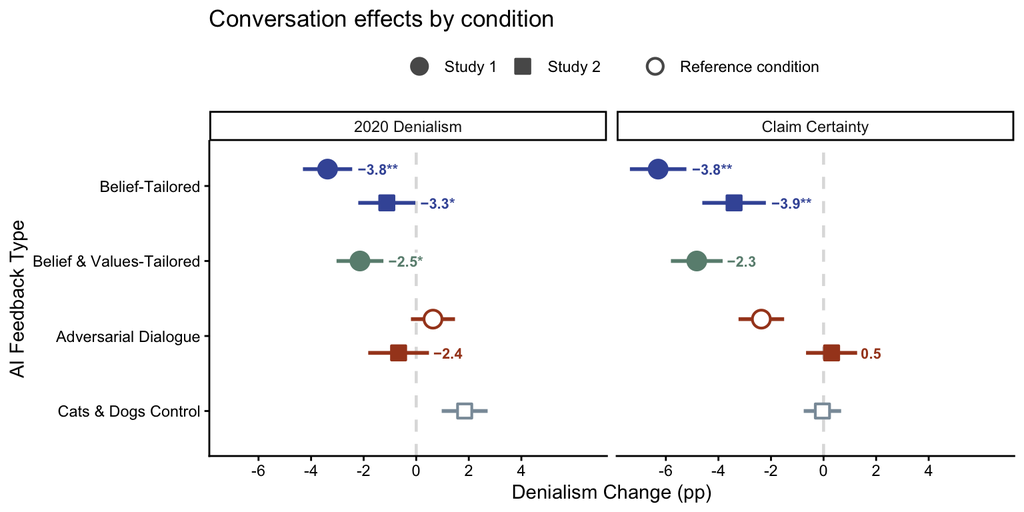

```r
models_s1 <- fit_model_list(dvs_post, dvs_precenter, df_consp, study = 1)
models_s2 <- fit_model_list(dvs_post, dvs_precenter, df_consp_2, study = 2)

reg_s1 <- hc1_tidy(models_s1)
reg_s2 <- hc1_tidy(models_s2)

# % change models for secondary figure labels
build_formula_perc <- function(dv, study) {
  if (study == 1) as.formula(paste(dv, "~ ConditionFeedback + ConditionChat"))
  else as.formula(paste(dv, "~ ConditionFeedback"))
}
fit_model_list_perc <- function(dvs, data, study) {
  models <- purrr::map(dvs, function(dv) {
    dc <- data %>% filter(!is.na(.data[[dv]]) & is.finite(.data[[dv]]))
    lm(build_formula_perc(dv, study), data = dc)
  })
  names(models) <- dvs
  models
}
models_perc_s1 <- fit_model_list_perc(dvs_perc, df_consp, study = 1)
models_perc_s2 <- fit_model_list_perc(dvs_perc, df_consp_2, study = 2)
regperc_s1 <- hc1_tidy(models_perc_s1)
regperc_s2 <- hc1_tidy(models_perc_s2)

fig2_outcomes     <- c("ER0Norm_Post" = "2020 Denialism", "Sureness_Post_1" = "Claim Certainty")
fig2_outcomes_pct <- c("ER0_PercChange" = "2020 Denialism", "Sureness_PercChange" = "Claim Certainty")

fig2_terms <- function(res_list, outs) {
  bind_rows(res_list) %>%
    filter(outcome %in% names(outs), startsWith(term, "ConditionFeedback")) %>%
    mutate(Outcome = unname(outs[outcome]), Condition = sub("^ConditionFeedback", "", term))
}
fig2_contrasts <- function(reg_list, regperc_list, study) {
  fig2_terms(reg_list, fig2_outcomes) %>%
    transmute(Study = as.character(study), Outcome, Condition, b = estimate, p = p.value) %>%
    left_join(fig2_terms(regperc_list, fig2_outcomes_pct) %>%
                transmute(Outcome, Condition, delta_pct = estimate, p_pct = p.value),
              by = c("Outcome", "Condition"))
}
fig2_contr <- bind_rows(fig2_contrasts(reg_s1, regperc_s1, 1), fig2_contrasts(reg_s2, regperc_s2, 2))

fmt_pct <- function(x) sub("^-", "−", sprintf("%+.1f%%", x))
fmt_b   <- function(x) sub("^-", "−", sprintf("%.1f", x))

fig2_label_stat <- "pp"
fig2_cond_colors <- c(condition_colors[c("Belief-Tailored", "Belief & Values-Tailored", "Adversarial Dialogue")],
                      Control = "#8A9BA8")
fig2_cond_order <- c("Belief-Tailored", "Belief & Values-Tailored", "Adversarial Dialogue", "Control")

fig2_pts <- df_both %>%
  filter(!is.na(ConditionFeedback)) %>%
  transmute(Study = as.character(Study), Condition = as.character(ConditionFeedback),
            `2020 Denialism` = ER0_Diff, `Claim Certainty` = Sureness_Diff) %>%
  pivot_longer(c(`2020 Denialism`, `Claim Certainty`), names_to = "Outcome", values_to = "y") %>%
  group_by(Study, Condition, Outcome) %>%
  summarise(m = mean(y, na.rm = TRUE), se = sd(y, na.rm = TRUE) / sqrt(sum(!is.na(y))), .groups = "drop") %>%
  left_join(fig2_contr, by = c("Study", "Condition", "Outcome")) %>%
  mutate(is_ref = is.na(b),
         Condition = factor(Condition, levels = rev(fig2_cond_order)),
         fill_key = ifelse(is_ref, "Reference condition", as.character(Condition)),
         lab = ifelse(is_ref, NA_character_,
                      paste0(if (fig2_label_stat == "pp") fmt_b(b) else fmt_pct(delta_pct), add_stars(p))))

fig2_dodge <- position_dodge(width = 0.9, reverse = TRUE)

figmain <- ggplot(fig2_pts, aes(x = m, y = Condition, group = Study)) +
  geom_vline(xintercept = 0, colour = "darkgray", alpha = .4, linewidth = 0.8, linetype = "dashed") +
  geom_linerange(aes(xmin = m - se, xmax = m + se, color = Condition), linewidth = 1, position = fig2_dodge) +
  geom_point(aes(shape = Study, color = Condition, fill = fill_key, size = Study), stroke = 1.1, position = fig2_dodge) +
  geom_label(aes(x = m + se, label = lab, color = Condition), fontface = "bold", na.rm = TRUE,
             position = fig2_dodge, hjust = -0.1, size = 2.9, fill = "white",
             linewidth = 0, label.padding = unit(0.08, "lines"), show.legend = FALSE) +
  scale_color_manual(values = fig2_cond_colors, guide = "none") +
  scale_fill_manual(values = c(fig2_cond_colors, `Reference condition` = "white"), breaks = "Reference condition",
                    labels = "Reference condition", name = NULL) +
  scale_shape_manual(values = c(`1` = 21, `2` = 22), labels = c("Study 1", "Study 2")) +
  scale_size_manual(values = c(`1` = 4, `2` = 3.5), guide = "none") +
  guides(shape = guide_legend(order = 1, override.aes = list(fill = "grey35", color = "grey35", size = 3.5)),
         fill  = guide_legend(order = 2, override.aes = list(shape = 21, fill = "white", color = "grey35", size = 3.5))) +
  scale_y_discrete(labels = c(Control = "Cats & Dogs Control")) +
  scale_x_continuous(breaks = seq(-8, 4, 2), expand = expansion(mult = c(0.05, 0.45))) +
  facet_wrap(~Outcome) +
  labs(x = "Denialism Change (pp)", y = "AI Feedback Type", title = "Conversation effects by condition",
       shape = NULL) +
  theme_classic() +
  theme(legend.title = element_text(size = 10, face = "bold"), legend.position = "top",
        plot.caption = element_text(size = 8, colour = "grey30", hjust = 0),
        plot.caption.position = "plot", legend.box = "horizontal")

figmain
```

```r
ggsave("figures/fig-denialism-changes.png", figmain, width = 8, height = 5, dpi = 600, create.dir = TRUE)
```

## 4. Standardized Treatment Effects (Studies 1 & 2)

Re-estimates primary models using standardized ($z$-scored) post-intervention outcomes to enable direct effect size comparisons across all measures.

```r
res_s1_std <- clean_regress(
  df_consp,
  dvs = dvs_post_std,
  type = "linear",
  predictors = ~ ConditionFeedback + ConditionChat,
  baseline = baseline_map_std,
  contrasts = "ConditionFeedback",
  vcov_type = "HC1",
  contrast_adjust = "tukey",
  dv_labels = new_labels2
)

res_s2_std <- clean_regress(
  df_consp_2,
  dvs = dvs_post_std,
  type = "linear",
  predictors = ~ ConditionFeedback,
  baseline = baseline_map_std,
  contrasts = "ConditionFeedback",
  vcov_type = "HC1",
  contrast_adjust = "tukey",
  dv_labels = new_labels2
)

cr_table(res_s1_std, style = "stargazer")
```

|  | 2020 Denialism (Main) Linear b | Claim Certainty Linear b | General Denialism Linear b | Specific Denialism Linear b | 2020 Denialism (Aggregate) Linear b | 2024 Denialism Linear b | Election Denialism (Aggregate) Linear b | Affective Polarization Linear b |
| --- | --- | --- | --- | --- | --- | --- | --- | --- |
| Intercept | 0.05 | 0.04 | 0.02 | 0.04 | 0.05 | 0.01 | 0.03 | 0.05 |
|  | (0.04) | (0.05) | (0.04) | (0.04) | (0.04) | (0.04) | (0.04) | (0.03) |
| Condition feedback |  |  |  |  |  |  |  |  |
| Adversarial dialogue (ref.) | — | — | — | — | — | — | — | — |
| Control |  |  |  |  |  |  |  |  |
| Belief & values tailored | -0.11* | -0.12 | 0.00 | -0.02 | -0.09 | 0.06 | -0.01 | 0.05 |
|  | (0.05) | (0.07) | (0.05) | (0.05) | (0.05) | (0.05) | (0.05) | (0.04) |
| Belief tailored | -0.17** | -0.20** | -0.12* | -0.03 | -0.12* | 0.07 | -0.09 | -0.02 |
|  | (0.06) | (0.07) | (0.05) | (0.05) | (0.05) | (0.05) | (0.05) | (0.04) |
| Condition chat |  |  |  |  |  |  |  |  |
| Chat (ref.) | — | — | — | — | — | — | — | — |
| Qualtrics | 0.06 | 0.06 | 0.06 | 0.06 | 0.09* | -0.03 | 0.07 | -0.03 |
|  | (0.05) | (0.06) | (0.04) | (0.04) | (0.04) | (0.04) | (0.04) | (0.03) |
| Baseline (centered) | 0.04*** | 0.03*** | 1.04*** | 0.91*** | 0.04*** | 0.69*** | 0.04*** | 0.02*** |
|  | (0.00) | (0.00) | (0.04) | (0.03) | (0.00) | (0.02) | (0.00) | (0.00) |
| Pairwise contrasts |  |  |  |  |  |  |  |  |
| Condition feedback |  |  |  |  |  |  |  |  |
| Belief & values tailored vs. Adversarial dialogue | -0.11 | -0.12 | 0.00 | -0.02 | -0.09 | 0.06 | -0.01 | 0.05 |
|  | (0.05) | (0.07) | (0.05) | (0.05) | (0.05) | (0.05) | (0.05) | (0.04) |
| Belief tailored vs. Adversarial dialogue | -0.17** | -0.20* | -0.12 | -0.03 | -0.12 | 0.07 | -0.09 | -0.02 |
|  | (0.06) | (0.07) | (0.05) | (0.05) | (0.05) | (0.05) | (0.05) | (0.04) |
| Belief tailored vs. Belief & values tailored | -0.06 | -0.08 | -0.12 | 0.00 | -0.03 | 0.02 | -0.08 | -0.07 |
|  | (0.06) | (0.07) | (0.05) | (0.05) | (0.05) | (0.05) | (0.05) | (0.04) |
| Model fit |  |  |  |  |  |  |  |  |
| Observations | 1,114 | 1,115 | 1,114 | 1,114 | 1,114 | 1,114 | 1,114 | 1,113 |
| R² | 0.45 | 0.20 | 0.51 | 0.53 | 0.52 | 0.49 | 0.57 | 0.72 |
| AIC | 2565.27 | 3053.87 | 2373.33 | 2344.93 | 2394.57 | 2429.45 | 2265.94 | 1638.58 |

Note. b = unstandardized coefficient; SE = standard error. SEs and p-values use HC1 robust SEs. Standard errors in parentheses. (ref.) marks the reference category for each factor. Pairwise contrasts compare estimated marginal means averaged over other predictors; their p-values and CIs are Tukey-adjusted within each factor. * p < .05. ** p < .01. *** p < .001.  
Empty cells: coefficient not estimable in that model (collinear or no observations).

```r
cr_table(res_s2_std, style = "stargazer")
```

|  | 2020 Denialism (Main) Linear b | Claim Certainty Linear b | General Denialism Linear b | Specific Denialism Linear b | 2020 Denialism (Aggregate) Linear b | 2024 Denialism Linear b | Election Denialism (Aggregate) Linear b | Affective Polarization Linear b |
| --- | --- | --- | --- | --- | --- | --- | --- | --- |
| Intercept | 0.11** | 0.13*** | -0.01 | -0.06 | 0.00 | -0.07 | -0.04 | -0.04 |
|  | (0.04) | (0.04) | (0.04) | (0.05) | (0.04) | (0.06) | (0.04) | (0.04) |
| Condition feedback |  |  |  |  |  |  |  |  |
| Control (ref.) | — | — | — | — | — | — | — | — |
| Adversarial dialogue | -0.11 | 0.03 | 0.04 | 0.03 | -0.04 | 0.09 | 0.04 | -0.11 |
|  | (0.06) | (0.06) | (0.06) | (0.07) | (0.06) | (0.08) | (0.05) | (0.06) |
| Belief & values tailored |  |  |  |  |  |  |  |  |
| Belief tailored | -0.15* | -0.21** | -0.09 | -0.13 | -0.15* | -0.08 | -0.11* | -0.10 |
|  | (0.06) | (0.07) | (0.06) | (0.07) | (0.07) | (0.08) | (0.06) | (0.06) |
| Baseline (centered) | 0.04*** | 0.04*** | 1.10*** | 0.84*** | 0.04*** | 0.64*** | 0.04*** | 0.02*** |
|  | (0.00) | (0.00) | (0.05) | (0.04) | (0.00) | (0.04) | (0.00) | (0.00) |
| Pairwise contrasts |  |  |  |  |  |  |  |  |
| Condition feedback |  |  |  |  |  |  |  |  |
| Adversarial dialogue vs. Control | -0.11 | 0.03 | 0.04 | 0.03 | -0.04 | 0.09 | 0.04 | -0.11 |
|  | (0.06) | (0.06) | (0.06) | (0.07) | (0.06) | (0.08) | (0.05) | (0.06) |
| Belief tailored vs. Control | -0.15* | -0.21** | -0.09 | -0.13 | -0.15 | -0.08 | -0.11 | -0.10 |
|  | (0.06) | (0.07) | (0.06) | (0.07) | (0.07) | (0.08) | (0.06) | (0.06) |
| Belief tailored vs. Adversarial dialogue | -0.04 | -0.23** | -0.13 | -0.16 | -0.11 | -0.17 | -0.15* | 0.01 |
|  | (0.07) | (0.08) | (0.06) | (0.07) | (0.07) | (0.08) | (0.05) | (0.06) |
| Model fit |  |  |  |  |  |  |  |  |
| Observations | 545 | 545 | 545 | 545 | 545 | 545 | 545 | 544 |
| R² | 0.56 | 0.41 | 0.67 | 0.51 | 0.56 | 0.44 | 0.71 | 0.71 |
| AIC | 1045.11 | 1098.62 | 961.05 | 1138.39 | 1052.84 | 1232.88 | 846.26 | 955.88 |

Note. b = unstandardized coefficient; SE = standard error. SEs and p-values use HC1 robust SEs. Standard errors in parentheses. (ref.) marks the reference category for each factor. Pairwise contrasts compare estimated marginal means averaged over other predictors; their p-values and CIs are Tukey-adjusted within each factor. * p < .05. ** p < .01. *** p < .001.  
Empty cells: coefficient not estimable in that model (collinear or no observations).

## 5. Preregistered Model Fit Comparison ($R^2$ & BIC)

Compares explained variance ($\Delta R^2$) and model parsimony ($\Delta \text{BIC}$) when adding treatment dummy indicators over baseline-only models.

```r
df_consp   <- df_consp   %>% mutate(ConditionChatDummy = if_else(ConditionChat == "Chat", 1, 0, missing = NA))
df_consp_2 <- df_consp_2 %>% mutate(ConditionChatDummy = if_else(ConditionChat == "Chat", 1, 0, missing = NA))

build_formula_baseline <- function(dv, dv_pre) as.formula(paste(dv, "~", dv_pre))
build_formula_full_dummy <- function(dv, dv_pre, study) {
  if (study == 1) as.formula(paste(dv, "~", dv_pre, "+ ConditionDet + ConditionPers + ConditionChatDummy"))
  else as.formula(paste(dv, "~", dv_pre, "+ ConditionDet + ConditionLim"))
}

model_fit_comparison <- function(dvs, dvs_pre, data, study) {
  purrr::map2_dfr(dvs, dvs_pre, function(dv, dv_pre) {
    m_base <- lm(build_formula_baseline(dv, dv_pre), data = data)
    m_full <- lm(build_formula_full_dummy(dv, dv_pre, study), data = data)
    tibble::tibble(
      Study        = study,
      DV           = dv,
      R2_baseline  = summary(m_base)$r.squared,
      R2_full      = summary(m_full)$r.squared,
      Delta_R2     = R2_full - R2_baseline,
      BIC_baseline = BIC(m_base),
      BIC_full     = BIC(m_full),
      Delta_BIC    = BIC_full - BIC_baseline,
      p_value      = anova(m_base, m_full)$`Pr(>F)`[2]
    )
  })
}

model_fit_s1 <- model_fit_comparison(dvs_post, dvs_precenter, df_consp, study = 1)
model_fit_s2 <- model_fit_comparison(dvs_post, dvs_precenter, df_consp_2, study = 2)

model_fit_summary <- bind_rows(model_fit_s1, model_fit_s2) %>%
  mutate(DV = dplyr::recode(DV, !!!new_labels)) %>%
  mutate(across(c(R2_baseline, R2_full, Delta_R2), ~round(.x, 3))) %>%
  mutate(across(c(BIC_baseline, BIC_full, Delta_BIC), ~round(.x, 1))) %>%
  mutate(p_value = signif(p_value, 3))

model_fit_summary %>%
  kable(caption = "Preregistered Model Fit Comparison: R² and BIC With vs. Without Treatment Dummies",
        align = "l") %>%
  kable_classic(full_width = FALSE, html_font = "Times New Roman") %>%
  kable_styling(bootstrap_options = c("striped", "hover", "responsive"),
                font_size = 12, fixed_thead = TRUE)
```

Preregistered Model Fit Comparison: R² and BIC With vs. Without Treatment Dummies

| Study | DV | R2_baseline | R2_full | Delta_R2 | BIC_baseline | BIC_full | Delta_BIC | p_value |
| --- | --- | --- | --- | --- | --- | --- | --- | --- |
| 1 | 2020 Denialism (Main) | 0.447 | 0.452 | 0.005 | 9438 | 9448 | 10.1 | 0.012 |
| 1 | Claim Certainty | 0.198 | 0.204 | 0.007 | 9636 | 9647 | 11.9 | 0.027 |
| 1 | General Denialism | 0.504 | 0.508 | 0.004 | 1812 | 1825 | 12.5 | 0.036 |
| 1 | Specific Denialism | 0.531 | 0.532 | 0.001 | 2044 | 2063 | 18.8 | 0.527 |
| 1 | 2020 Denialism (Aggregate) | 0.520 | 0.524 | 0.004 | 9237 | 9248 | 11.3 | 0.021 |
| 1 | 2024 Denialism | 0.487 | 0.488 | 0.001 | 2536 | 2555 | 18.7 | 0.510 |
| 1 | Election Denialism (Aggregate) | 0.563 | 0.565 | 0.003 | 9029 | 9044 | 14.6 | 0.091 |
| 1 | Affective Polarization | 0.722 | 0.724 | 0.001 | 9601 | 9617 | 16.6 | 0.215 |
| 2 | 2020 Denialism (Main) | 0.550 | 0.555 | 0.005 | 4413 | 4419 | 6.6 | 0.051 |
| 2 | Claim Certainty | 0.397 | 0.412 | 0.015 | 4330 | 4328 | -1.4 | 0.001 |
| 2 | General Denialism | 0.668 | 0.670 | 0.003 | 692 | 700 | 7.9 | 0.098 |
| 2 | Specific Denialism | 0.508 | 0.513 | 0.005 | 1000 | 1007 | 7.0 | 0.063 |
| 2 | 2020 Denialism (Aggregate) | 0.556 | 0.561 | 0.005 | 4406 | 4413 | 6.8 | 0.056 |
| 2 | 2024 Denialism | 0.436 | 0.441 | 0.005 | 1293 | 1301 | 8.1 | 0.106 |
| 2 | Election Denialism (Aggregate) | 0.711 | 0.715 | 0.004 | 4165 | 4169 | 4.2 | 0.016 |
| 2 | Affective Polarization | 0.711 | 0.713 | 0.002 | 4854 | 4862 | 8.7 | 0.144 |

## 6. Pooled Treatment Effects (Studies 1 & 2)

Pooled models across both studies estimating overall feedback effects on 2020 Denialism and Claim Certainty (reference: Cats & Dogs Control, with study fixed effects).

```r
df_both$ConditionFeedback = relevel(df_both$ConditionFeedback, ref = "Control")
df_both$StudyFactor       = factor(df_both$Study)

res_pooled <- clean_regress(
  df_both,
  dvs = c("ER0Norm_Post", "Sureness_Post_1"),
  type = "linear",
  predictors = ~ ConditionFeedback + StudyFactor,
  baseline = baseline_map[c("ER0Norm_Post", "Sureness_Post_1")],
  contrasts = "ConditionFeedback",
  vcov_type = "HC1",
  contrast_adjust = "tukey",
  dv_labels = new_labels[c("ER0Norm_Post", "Sureness_Post_1")]
)

cr_table(res_pooled, style = "stargazer")
```

|  | 2020 Denialism (Main) Linear b | Claim Certainty Linear b |
| --- | --- | --- |
| Intercept | 80.17*** | 85.30*** |
|  | (1.29) | (1.19) |
| Condition feedback |  |  |
| Control (ref.) | — | — |
| Adversarial dialogue | -1.43 | 0.22 |
|  | (1.24) | (1.07) |
| Belief & values tailored | -3.45* | -2.21 |
|  | (1.55) | (1.52) |
| Belief tailored | -4.22*** | -3.75** |
|  | (1.23) | (1.15) |
| Study factor |  |  |
| 1 (ref.) | — | — |
| 2 | 0.33 | 2.21* |
|  | (0.98) | (0.98) |
| Baseline (centered) | 0.78*** | 0.64*** |
|  | (0.02) | (0.03) |
| Pairwise contrasts |  |  |
| Condition feedback |  |  |
| Adversarial dialogue vs. Control | -1.43 | 0.22 |
|  | (1.24) | (1.07) |
| Belief & values tailored vs. Control | -3.45 | -2.21 |
|  | (1.55) | (1.52) |
| Belief & values tailored vs. Adversarial dialogue | -2.01 | -2.44 |
|  | (1.12) | (1.21) |
| Belief tailored vs. Control | -4.22** | -3.75** |
|  | (1.23) | (1.15) |
| Belief tailored vs. Adversarial dialogue | -2.79* | -3.97*** |
|  | (0.96) | (1.01) |
| Belief tailored vs. Belief & values tailored | -0.78 | -1.54 |
|  | (1.19) | (1.31) |
| Model fit |  |  |
| Observations | 1,659 | 1,660 |
| R² | 0.48 | 0.25 |
| AIC | 13839.36 | 14006.91 |

Note. b = unstandardized coefficient; SE = standard error. SEs and p-values use HC1 robust SEs. Standard errors in parentheses. (ref.) marks the reference category for each factor. Pairwise contrasts compare estimated marginal means averaged over other predictors; their p-values and CIs are Tukey-adjusted within each factor. * p < .05. ** p < .01. *** p < .001.

## 7. Downstream Voting Likelihood (Study 2)

Examines whether conversational AI interventions affected participants’ self-reported likelihood of voting in the 2024 presidential election (0–100 scale) or candidate preference lean (Harris vs. Trump).

```r
df_vote_s2 <- df_both %>% filter(Study == 2)

res_vote <- clean_regress(
  df_vote_s2,
  dvs = c(Vote_Post_1 = "linear"),
  predictors = ~ ConditionFeedback,
  baseline = c(Vote_Post_1 = "Vote_Pre_1"),
  contrasts = "ConditionFeedback",
  vcov_type = "HC1",
  contrast_adjust = "tukey",
  dv_labels = c(Vote_Post_1 = "2024 Voting Likelihood (0-100)")
)

res_lean <- clean_regress(
  df_both,
  dvs = c(lean_bidentrump_Post_4 = "linear"),
  predictors = ~ ConditionFeedback,
  contrasts = "ConditionFeedback",
  vcov_type = "HC1",
  contrast_adjust = "tukey",
  dv_labels = c(lean_bidentrump_Post_4 = "Vote Lean (Harris vs. Trump)")
)

cr_table(res_vote, style = "stargazer")
```

|  | 2024 Voting Likelihood (0-100) Linear b |
| --- | --- |
| Intercept | 90.83*** |
|  | (0.64) |
| Condition feedback |  |
| Control (ref.) | — |
| Adversarial dialogue | 1.30 |
|  | (0.90) |
| Belief & values tailored |  |
| Belief tailored | 1.02 |
|  | (0.89) |
| Baseline (centered) | 0.85*** |
|  | (0.03) |
| Pairwise contrasts |  |
| Condition feedback |  |
| Adversarial dialogue vs. Control | 1.30 |
|  | (0.90) |
| Belief tailored vs. Control | 1.02 |
|  | (0.89) |
| Belief tailored vs. Adversarial dialogue | -0.28 |
|  | (0.89) |
| Model fit |  |
| Observations | 545 |
| R² | 0.75 |
| AIC | 3885.31 |

Note. b = unstandardized coefficient; SE = standard error. SEs and p-values use HC1 robust SEs. Standard errors in parentheses. (ref.) marks the reference category for each factor. Pairwise contrasts compare estimated marginal means averaged over other predictors; their p-values and CIs are Tukey-adjusted within each factor. * p < .05. ** p < .01. *** p < .001.  
Empty cells: coefficient not estimable in that model (collinear or no observations).

```r
cr_table(res_lean, style = "stargazer")
```

|  | Vote Lean (Harris vs. Trump) Linear b |
| --- | --- |
| Intercept | 89.93*** |
|  | (1.24) |
| Condition feedback |  |
| Control (ref.) | — |
| Adversarial dialogue | -0.98 |
|  | (1.88) |
| Belief & values tailored |  |
| Belief tailored | -0.93 |
|  | (1.84) |
| Pairwise contrasts |  |
| Condition feedback |  |
| Adversarial dialogue vs. Control | -0.98 |
|  | (1.88) |
| Belief tailored vs. Control | -0.93 |
|  | (1.84) |
| Belief tailored vs. Adversarial dialogue | 0.05 |
|  | (1.95) |
| Model fit |  |
| Observations | 545 |
| R² | 0.00 |
| AIC | 4701.65 |

Note. b = unstandardized coefficient; SE = standard error. SEs and p-values use HC1 robust SEs. Standard errors in parentheses. (ref.) marks the reference category for each factor. Pairwise contrasts compare estimated marginal means averaged over other predictors; their p-values and CIs are Tukey-adjusted within each factor. * p < .05. ** p < .01. *** p < .001.  
Empty cells: coefficient not estimable in that model (collinear or no observations).

# PART II: SUPPLEMENTARY FIGURES & SENSITIVITY ANALYSES

## 8. Supplementary Figures: Multi-Outcome Treatment Effects (`fig-effects`)

Generates Figures C1 & C2: Baseline-adjusted and demographic-covariate-adjusted treatment effects across all five denialism outcomes on a 0–100 normalized scale.

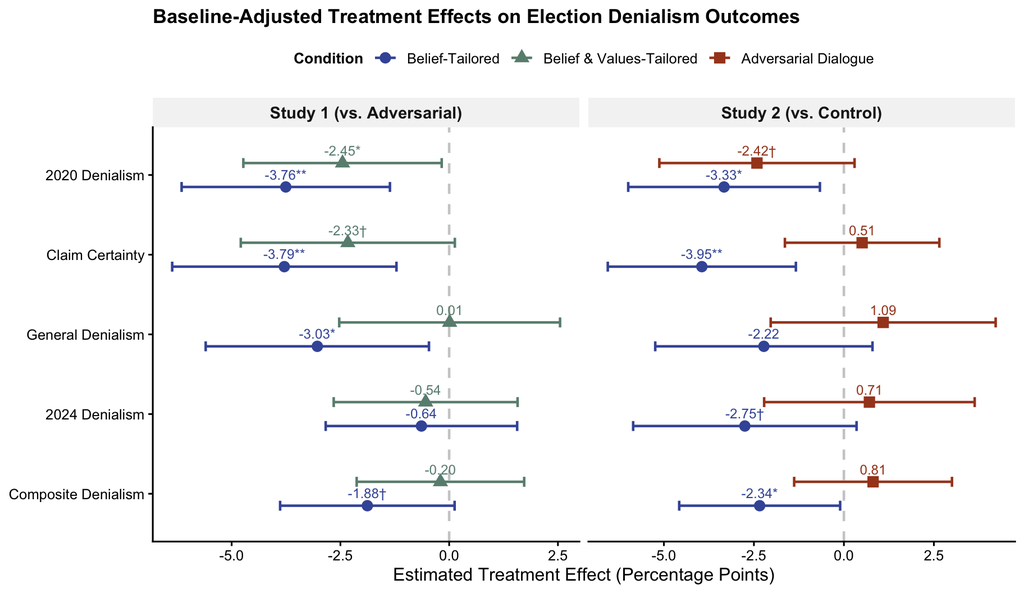

```r
supp_covs_s1 <- c('ConditionChat', 'Race', 'Age', 'GenderClean', 'Education', 'religion', 'DemRep_C.text',
                  'EconomicConservatism', 'SocialConservatism', 'VoteMethod.text', 'AffPol_Pre',
                  'PartyAffil.text', 'PartyReg.text', 'VoteFor2020.clean', 'Vote_1', 'Vote_Post_1',
                  'InstTrust_USGov', 'InstTrust_CivilService', 'InstTrust_Media', 'InstTrust_Banks',
                  'InstTrust_MajorCompanies', 'genai_trust', 'genai_fam_1', 'genai_use_1')

supp_covs_s2 <- c('Race', 'Age', 'GenderClean', 'Education', 'religion', 'DemRep_C.text',
                  'VoteMethod.text', 'AffPol_Pre', 'PartyAffil.text', 'VoteFor2020.clean',
                  'Vote_Post_1', 'InstTrust_USGov', 'InstTrust_Media', 'genai_trust', 'genai_fam_1', 'genai_use_1')

supp_d1 <- df_consp
supp_d2 <- df_consp_2
supp_d1$ConditionFeedback <- relevel(factor(supp_d1$ConditionFeedback), ref = 'Adversarial Dialogue')
supp_d2$ConditionFeedback <- relevel(factor(supp_d2$ConditionFeedback), ref = 'Control')

supp_outcomes_map <- list(
  '2020 Denialism'      = list(post = 'ER0Norm_Post', pre = 'ER0Norm_Pre_center'),
  'Claim Certainty'     = list(post = 'Sureness_Post_1', pre = 'Sureness_Pre_center'),
  'General Denialism'   = list(post = 'ER1Norm_Post', pre = 'ER1_Pre_center'),
  '2024 Denialism'      = list(post = 'ER2Norm_Post', pre = 'ER2_Pre_center'),
  'Composite Denialism' = list(post = 'ER_Post', pre = 'ERNorm_Pre_center')
)

fit_supp_data <- function(use_covars = FALSE) {
  res <- list()
  for (nm in names(supp_outcomes_map)) {
    om <- supp_outcomes_map[[nm]]
    f1_str <- if (use_covars) {
      paste(om$post, '~ ConditionFeedback +', om$pre, '+', paste(supp_covs_s1, collapse = ' + '))
    } else {
      paste(om$post, '~ ConditionFeedback + ConditionChat +', om$pre)
    }
    m1 <- lm(as.formula(f1_str), data = supp_d1)
    c1 <- lmtest::coeftest(m1, vcov = sandwich::vcovHC(m1, type = 'HC1'))
    for (t in c('Belief-Tailored', 'Belief & Values-Tailored')) {
      rn <- paste0('ConditionFeedback', t)
      if (rn %in% rownames(c1)) {
        res[[length(res)+1]] <- data.frame(
          Study = 'Study 1 (vs. Adversarial)', Outcome = nm, Condition = t,
          Estimate = c1[rn, 1], SE = c1[rn, 2], p = c1[rn, 4], stringsAsFactors = FALSE
        )
      }
    }
    f2_str <- if (use_covars) {
      paste(om$post, '~ ConditionFeedback +', om$pre, '+', paste(supp_covs_s2, collapse = ' + '))
    } else {
      paste(om$post, '~ ConditionFeedback +', om$pre)
    }
    m2 <- lm(as.formula(f2_str), data = supp_d2)
    c2 <- lmtest::coeftest(m2, vcov = sandwich::vcovHC(m2, type = 'HC1'))
    for (t in c('Belief-Tailored', 'Adversarial Dialogue')) {
      rn <- paste0('ConditionFeedback', t)
      if (rn %in% rownames(c2)) {
        res[[length(res)+1]] <- data.frame(
          Study = 'Study 2 (vs. Control)', Outcome = nm, Condition = t,
          Estimate = c2[rn, 1], SE = c2[rn, 2], p = c2[rn, 4], stringsAsFactors = FALSE
        )
      }
    }
  }
  dplyr::bind_rows(res)
}

plot_supp_effects <- function(df_data, title_text) {
  df_data <- df_data %>%
    dplyr::mutate(
      Outcome = factor(Outcome, levels = rev(c('2020 Denialism', 'Claim Certainty', 'General Denialism', '2024 Denialism', 'Composite Denialism'))),
      Condition = factor(Condition, levels = c('Belief-Tailored', 'Belief & Values-Tailored', 'Adversarial Dialogue')),
      ci_lo = Estimate - 1.96 * SE,
      ci_hi = Estimate + 1.96 * SE,
      sig = dplyr::case_when(
        p < 0.001 ~ '***',
        p < 0.01  ~ '**',
        p < 0.05  ~ '*',
        p < 0.10  ~ '\u2020',
        TRUE      ~ ''
      ),
      lbl = sprintf('%.2f%s', Estimate, sig)
    )

  col_map <- c(
    'Belief-Tailored'          = '#4158A6',
    'Belief & Values-Tailored' = '#6A8E7F',
    'Adversarial Dialogue'     = '#A64521'
  )

  ggplot(df_data, aes(x = Estimate, y = Outcome, color = Condition, shape = Condition)) +
    geom_vline(xintercept = 0, colour = 'darkgray', alpha = 0.6, linewidth = 0.8, linetype = 'dashed') +
    geom_errorbarh(aes(xmin = ci_lo, xmax = ci_hi), height = 0.25, linewidth = 0.8, position = position_dodge(width = 0.6)) +
    geom_point(size = 3.2, position = position_dodge(width = 0.6)) +
    geom_text(aes(label = lbl), position = position_dodge(width = 0.6), vjust = -0.8, size = 3.2, show.legend = FALSE) +
    facet_wrap(~ Study, scales = 'free_x') +
    scale_color_manual(values = col_map) +
    labs(
      title = title_text,
      x = 'Estimated Treatment Effect (Percentage Points)',
      y = NULL
    ) +
    theme_classic(base_size = 12) +
    theme(
      legend.position = 'top',
      legend.title = element_text(size = 10, face = 'bold'),
      strip.background = element_rect(fill = '#f4f4f4', color = NA),
      strip.text = element_text(face = 'bold', size = 11),
      plot.title = element_text(face = 'bold', size = 13)
    )
}

p_supp_unadj <- plot_supp_effects(fit_supp_data(use_covars = FALSE), 'Baseline-Adjusted Treatment Effects on Election Denialism Outcomes')
p_supp_adj   <- plot_supp_effects(fit_supp_data(use_covars = TRUE),   'Covariate-Adjusted Treatment Effects on Election Denialism Outcomes')

p_supp_unadj
```

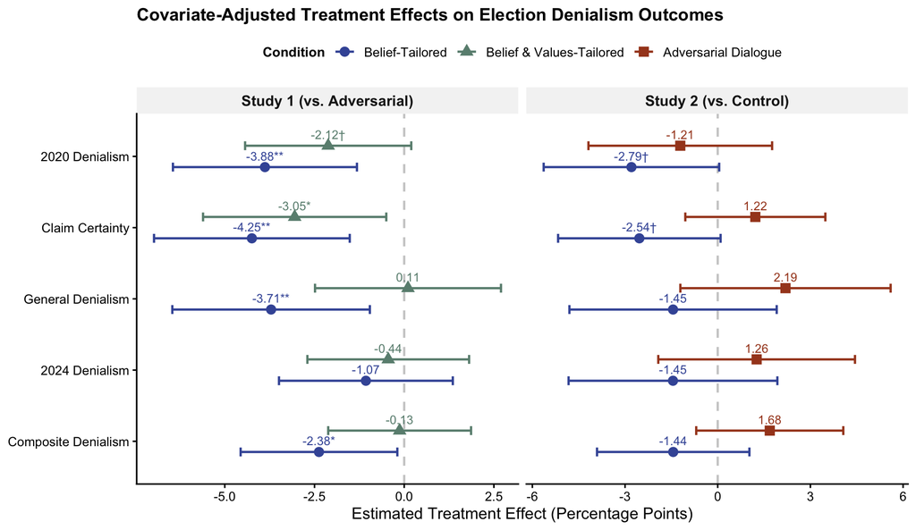

```r
p_supp_adj
```

```r
dir.create("figures/supplement", recursive = TRUE, showWarnings = FALSE)
ggsave("figures/supplement/fig-effects.png", p_supp_unadj, width = 9.5, height = 5.5, dpi = 300)
ggsave("figures/supplement/fig-effects-adjusted.png", p_supp_adj, width = 9.5, height = 5.5, dpi = 300)

dir.create("../5-disseminate/figures/supplement", recursive = TRUE, showWarnings = FALSE)
ggsave("../5-disseminate/figures/supplement/fig-effects.png", p_supp_unadj, width = 9.5, height = 5.5, dpi = 300)
ggsave("../5-disseminate/figures/supplement/fig-effects-adjusted.png", p_supp_adj, width = 9.5, height = 5.5, dpi = 300)
```

## 9. Interface Moderation (Study 1 Condition × Interface Interaction)

Tests the preregistered interaction between conversational feedback condition and interface delivery mode (Chat vs. Qualtrics).

```r
res_s1_int <- clean_regress(
  df_consp,
  dvs = dvs_post,
  type = "linear",
  predictors = ~ ConditionFeedback * ConditionChat,
  baseline = baseline_map,
  vcov_type = "HC1",
  dv_labels = new_labels
)

cr_table(res_s1_int, style = "stargazer")
```

|  | 2020 Denialism (Main) Linear b | Claim Certainty Linear b | General Denialism Linear b | Specific Denialism Linear b | 2020 Denialism (Aggregate) Linear b | 2024 Denialism Linear b | Election Denialism (Aggregate) Linear b | Affective Polarization Linear b |
| --- | --- | --- | --- | --- | --- | --- | --- | --- |
| Intercept | 79.29*** | 84.85*** | 3.15*** | 3.54*** | 72.74*** | 3.06*** | 67.51*** | 52.93*** |
|  | (1.15) | (1.29) | (0.04) | (0.04) | (1.03) | (0.06) | (1.00) | (1.26) |
| Condition feedback |  |  |  |  |  |  |  |  |
| Adversarial dialogue (ref.) | — | — | — | — | — | — | — | — |
| Control |  |  |  |  |  |  |  |  |
| Belief & values tailored | -3.85* | -1.54 | -0.01 | -0.08 | -3.82* | 0.06 | -0.99 | 2.94 |
|  | (1.66) | (1.82) | (0.06) | (0.06) | (1.51) | (0.08) | (1.40) | (1.82) |
| Belief tailored | -3.74* | -3.81 | -0.13* | -0.12 | -4.57** | 0.04 | -3.66* | -1.12 |
|  | (1.86) | (2.11) | (0.06) | (0.07) | (1.68) | (0.08) | (1.61) | (1.90) |
| Condition chat |  |  |  |  |  |  |  |  |
| Chat (ref.) | — | — | — | — | — | — | — | — |
| Qualtrics | 0.23 | 1.80 | 0.02 | -0.05 | -0.72 | -0.05 | -0.29 | -0.52 |
|  | (1.56) | (1.62) | (0.05) | (0.06) | (1.40) | (0.08) | (1.35) | (1.94) |
| Baseline (centered) | 0.77*** | 0.62*** | 0.80*** | 0.79*** | 0.79*** | 0.72*** | 0.85*** | 0.87*** |
|  | (0.03) | (0.04) | (0.03) | (0.02) | (0.02) | (0.02) | (0.02) | (0.02) |
| Control × Qualtrics |  |  |  |  |  |  |  |  |
| Belief & values tailored × Qualtrics | 2.90 | -1.65 | 0.01 | 0.12 | 4.01 | 0.00 | 1.69 | -2.36 |
|  | (2.31) | (2.50) | (0.08) | (0.09) | (2.12) | (0.11) | (1.96) | (2.62) |
| Belief tailored × Qualtrics | 0.11 | -0.05 | 0.08 | 0.18* | 4.10 | 0.07 | 3.50 | 0.97 |
|  | (2.45) | (2.64) | (0.08) | (0.09) | (2.22) | (0.11) | (2.06) | (2.68) |
| Model fit |  |  |  |  |  |  |  |  |
| Observations | 1,114 | 1,115 | 1,114 | 1,114 | 1,114 | 1,114 | 1,114 | 1,113 |
| R² | 0.45 | 0.20 | 0.51 | 0.53 | 0.53 | 0.49 | 0.57 | 0.72 |
| AIC | 9420.41 | 9620.75 | 1797.88 | 2032.41 | 9217.91 | 2528.57 | 9014.91 | 9589.34 |

Note. b = unstandardized coefficient; SE = standard error. SEs and p-values use HC1 robust SEs. Standard errors in parentheses. (ref.) marks the reference category for each factor. * p < .05. ** p < .01. *** p < .001.  
Empty cells: coefficient not estimable in that model (collinear or no observations).

## 10. Preregistered Sample (Without NLP Filtering)

Re-estimates models on all participants meeting preregistered screening criteria without applying open-ended NLP conspiracy claim filtering.

```r
df_prereg <- df_all %>%
  dplyr::filter(
    ScreenedDummy == 0,
    ER0Norm_Pre > 25,
    screenquality >= 2,
    `Duration (in seconds)` > 600,
    Study == 1)

df_prereg_2 <- df_all %>%
  dplyr::filter(
    ScreenedDummy == 0,
    ER0Norm_Pre > 25,
    screenquality >= 2,
    `Duration (in seconds)` > 600,
    Study == 2)

for (d in c("df_prereg", "df_prereg_2")) {
  df <- get(d)
  for (nm in names(pre_center_map)) {
    x <- as.numeric(df[[pre_center_map[[nm]]]])
    df[[nm]] <- x - ave(x, df$Study, FUN = function(v) mean(v, na.rm = TRUE))
  }
  assign(d, df)
}

res_prereg_s1 <- clean_regress(
  df_prereg,
  dvs = dvs_post,
  type = "linear",
  predictors = ~ ConditionFeedback + ConditionChat,
  baseline = baseline_map,
  contrasts = "ConditionFeedback",
  vcov_type = "HC1",
  contrast_adjust = "tukey",
  dv_labels = new_labels
)

res_prereg_s2 <- clean_regress(
  df_prereg_2,
  dvs = dvs_post,
  type = "linear",
  predictors = ~ ConditionFeedback,
  baseline = baseline_map,
  contrasts = "ConditionFeedback",
  vcov_type = "HC1",
  contrast_adjust = "tukey",
  dv_labels = new_labels
)

cr_table(res_prereg_s1, style = "stargazer")
```

|  | 2020 Denialism (Main) Linear b | Claim Certainty Linear b | General Denialism Linear b | Specific Denialism Linear b | 2020 Denialism (Aggregate) Linear b | 2024 Denialism Linear b | Election Denialism (Aggregate) Linear b | Affective Polarization Linear b |
| --- | --- | --- | --- | --- | --- | --- | --- | --- |
| Intercept | 73.66*** | 85.05*** | 2.96*** | 3.24*** | 65.62*** | 2.81*** | 60.59*** | 45.08*** |
|  | (0.85) | (0.72) | (0.02) | (0.03) | (0.68) | (0.04) | (0.62) | (0.94) |
| Condition feedback |  |  |  |  |  |  |  |  |
| Control (ref.) | — | — | — | — | — | — | — | — |
| Adversarial dialogue |  |  |  |  |  |  |  |  |
| Belief & values tailored | -2.01 | -1.36 | 0.04 | -0.02 | -1.58 | 0.03 | 0.37 | 1.68 |
|  | (1.09) | (0.98) | (0.03) | (0.04) | (0.89) | (0.05) | (0.80) | (1.08) |
| Belief tailored | -2.48* | -2.35* | -0.04 | -0.01 | -1.69 | 0.06 | -0.78 | -0.53 |
|  | (1.09) | (1.04) | (0.03) | (0.04) | (0.90) | (0.05) | (0.82) | (1.08) |
| Condition chat |  |  |  |  |  |  |  |  |
| Qualtrics (ref.) | — | — | — | — | — | — | — | — |
| Chat | -0.41 | -1.54 | -0.02 | -0.02 | -0.67 | 0.01 | -0.44 | 1.18 |
|  | (0.89) | (0.85) | (0.03) | (0.03) | (0.74) | (0.04) | (0.67) | (0.89) |
| Baseline (centered) | 0.84*** | 0.52*** | 0.85*** | 0.80*** | 0.83*** | 0.69*** | 0.88*** | 0.87*** |
|  | (0.02) | (0.03) | (0.02) | (0.02) | (0.02) | (0.02) | (0.02) | (0.02) |
| Pairwise contrasts |  |  |  |  |  |  |  |  |
| Condition feedback |  |  |  |  |  |  |  |  |
| Belief & values tailored vs. Adversarial dialogue | -2.01 | -1.36 | 0.04 | -0.02 | -1.58 | 0.03 | 0.37 | 1.68 |
|  | (1.09) | (0.98) | (0.03) | (0.04) | (0.89) | (0.05) | (0.80) | (1.08) |
| Belief tailored vs. Adversarial dialogue | -2.48 | -2.35 | -0.04 | -0.01 | -1.69 | 0.06 | -0.78 | -0.53 |
|  | (1.09) | (1.04) | (0.03) | (0.04) | (0.90) | (0.05) | (0.82) | (1.08) |
| Belief tailored vs. Belief & values tailored | -0.47 | -1.00 | -0.08 | 0.01 | -0.11 | 0.03 | -1.16 | -2.22 |
|  | (1.11) | (1.09) | (0.03) | (0.04) | (0.94) | (0.05) | (0.84) | (1.06) |
| Model fit |  |  |  |  |  |  |  |  |
| Observations | 1,675 | 1,675 | 1,675 | 1,675 | 1,675 | 1,675 | 1,675 | 1,673 |
| R² | 0.48 | 0.22 | 0.58 | 0.58 | 0.59 | 0.46 | 0.64 | 0.74 |
| AIC | 14490.02 | 14305.59 | 2735.24 | 3090.18 | 13867.98 | 4042.52 | 13525.11 | 14424.06 |

Note. b = unstandardized coefficient; SE = standard error. SEs and p-values use HC1 robust SEs. Standard errors in parentheses. (ref.) marks the reference category for each factor. Pairwise contrasts compare estimated marginal means averaged over other predictors; their p-values and CIs are Tukey-adjusted within each factor. * p < .05. ** p < .01. *** p < .001.  
Empty cells: coefficient not estimable in that model (collinear or no observations).

```r
cr_table(res_prereg_s2, style = "stargazer")
```

|  | 2020 Denialism (Main) Linear b | Claim Certainty Linear b | General Denialism Linear b | Specific Denialism Linear b | 2020 Denialism (Aggregate) Linear b | 2024 Denialism Linear b | Election Denialism (Aggregate) Linear b | Affective Polarization Linear b |
| --- | --- | --- | --- | --- | --- | --- | --- | --- |
| Intercept | 73.60*** | 83.56*** | 2.75*** | 3.07*** | 61.77*** | 2.73*** | 54.95*** | 39.68*** |
|  | (0.83) | (0.60) | (0.03) | (0.03) | (0.75) | (0.05) | (0.62) | (1.05) |
| Condition feedback |  |  |  |  |  |  |  |  |
| Control (ref.) | — | — | — | — | — | — | — | — |
| Adversarial dialogue | -3.34* | 0.14 | 0.05 | 0.00 | -1.55 | 0.05 | 1.03 | -3.88* |
|  | (1.33) | (0.92) | (0.04) | (0.05) | (1.10) | (0.07) | (0.92) | (1.70) |
| Belief & values tailored |  |  |  |  |  |  |  |  |
| Belief tailored | -2.79* | -3.08** | 0.04 | -0.08 | -2.50* | -0.07 | -0.18 | -1.96 |
|  | (1.27) | (1.01) | (0.04) | (0.05) | (1.10) | (0.07) | (0.88) | (1.60) |
| Baseline (centered) | 0.82*** | 0.68*** | 0.86*** | 0.75*** | 0.81*** | 0.61*** | 0.87*** | 0.86*** |
|  | (0.03) | (0.03) | (0.02) | (0.02) | (0.02) | (0.03) | (0.02) | (0.02) |
| Pairwise contrasts |  |  |  |  |  |  |  |  |
| Condition feedback |  |  |  |  |  |  |  |  |
| Adversarial dialogue vs. Control | -3.34* | 0.14 | 0.05 | 0.00 | -1.55 | 0.05 | 1.03 | -3.88 |
|  | (1.33) | (0.92) | (0.04) | (0.05) | (1.10) | (0.07) | (0.92) | (1.70) |
| Belief tailored vs. Control | -2.79 | -3.08** | 0.04 | -0.08 | -2.50 | -0.07 | -0.18 | -1.96 |
|  | (1.27) | (1.01) | (0.04) | (0.05) | (1.10) | (0.07) | (0.88) | (1.60) |
| Belief tailored vs. Adversarial dialogue | 0.54 | -3.22** | -0.01 | -0.08 | -0.94 | -0.13 | -1.21 | 1.93 |
|  | (1.41) | (1.07) | (0.04) | (0.05) | (1.15) | (0.07) | (0.93) | (1.79) |
| Model fit |  |  |  |  |  |  |  |  |
| Observations | 971 | 972 | 971 | 971 | 971 | 971 | 971 | 970 |
| R² | 0.46 | 0.45 | 0.71 | 0.54 | 0.57 | 0.37 | 0.73 | 0.67 |
| AIC | 8259.00 | 7720.92 | 1331.43 | 1804.29 | 7919.29 | 2495.50 | 7523.13 | 8705.96 |

Note. b = unstandardized coefficient; SE = standard error. SEs and p-values use HC1 robust SEs. Standard errors in parentheses. (ref.) marks the reference category for each factor. Pairwise contrasts compare estimated marginal means averaged over other predictors; their p-values and CIs are Tukey-adjusted within each factor. * p < .05. ** p < .01. *** p < .001.  
Empty cells: coefficient not estimable in that model (collinear or no observations).

## 11. Percentage Change from Baseline Specification

Regresses individual percentage change from baseline (`(Post - Pre) / Pre * 100`) on condition without baseline covariate adjustment.

```r
res_perc_s1 <- clean_regress(
  df_consp,
  dvs = dvs_perc,
  type = "linear",
  predictors = ~ ConditionFeedback + ConditionChat,
  contrasts = "ConditionFeedback",
  vcov_type = "HC1",
  contrast_adjust = "tukey",
  dv_labels = new_labelsperc
)

res_perc_s2 <- clean_regress(
  df_consp_2,
  dvs = dvs_perc,
  type = "linear",
  predictors = ~ ConditionFeedback,
  contrasts = "ConditionFeedback",
  vcov_type = "HC1",
  contrast_adjust = "tukey",
  dv_labels = new_labelsperc
)

cr_table(res_perc_s1, style = "stargazer")
```

|  | 2020 Denialism (Main) Linear b | Claim Certainty Linear b | General Denialism Linear b | Specific Denialism Linear b | 2020 Denialism (Aggregate) Linear b | 2024 Denialism Linear b | Election Denialism (Aggregate) Linear b | Affective Polarization Linear b |
| --- | --- | --- | --- | --- | --- | --- | --- | --- |
| Intercept | 3.20 | -1.42 | -2.64 | -4.33*** | -3.05* | 0.61 | -5.20*** | -32.74 |
|  | (1.70) | (1.49) | (1.39) | (1.15) | (1.45) | (2.05) | (1.50) | (32.78) |
| Condition feedback |  |  |  |  |  |  |  |  |
| Adversarial dialogue (ref.) | — | — | — | — | — | — | — | — |
| Control |  |  |  |  |  |  |  |  |
| Belief & values tailored | -4.89* | -2.95 | 0.47 | 0.09 | -2.16 | 1.65 | -0.12 | 27.78 |
|  | (2.01) | (1.76) | (1.80) | (1.51) | (1.92) | (2.68) | (1.84) | (27.84) |
| Belief tailored | -7.66*** | -4.56** | -3.98** | -1.01 | -4.39* | 0.31 | -3.81* | 20.26 |
|  | (2.01) | (1.75) | (1.45) | (1.30) | (1.71) | (2.46) | (1.67) | (24.74) |
| Condition chat |  |  |  |  |  |  |  |  |
| Chat (ref.) | — | — | — | — | — | — | — | — |
| Qualtrics | 1.25 | 0.31 | 2.00 | 1.74 | 3.01 | -1.04 | 2.61 | 12.08 |
|  | (1.63) | (1.46) | (1.39) | (1.19) | (1.54) | (2.07) | (1.46) | (18.36) |
| Pairwise contrasts |  |  |  |  |  |  |  |  |
| Condition feedback |  |  |  |  |  |  |  |  |
| Belief & values tailored vs. Adversarial dialogue | -4.89* | -2.95 | 0.47 | 0.09 | -2.16 | 1.65 | -0.12 | 27.78 |
|  | (2.01) | (1.76) | (1.80) | (1.51) | (1.92) | (2.68) | (1.84) | (27.84) |
| Belief tailored vs. Adversarial dialogue | -7.66*** | -4.56* | -3.98* | -1.01 | -4.39* | 0.31 | -3.81 | 20.26 |
|  | (2.01) | (1.75) | (1.45) | (1.30) | (1.71) | (2.46) | (1.67) | (24.74) |
| Belief tailored vs. Belief & values tailored | -2.77 | -1.61 | -4.45* | -1.10 | -2.23 | -1.33 | -3.69 | -7.52 |
|  | (1.95) | (1.85) | (1.77) | (1.53) | (1.99) | (2.31) | (1.84) | (12.33) |
| Model fit |  |  |  |  |  |  |  |  |
| Observations | 1,114 | 1,115 | 1,114 | 1,114 | 1,114 | 1,114 | 1,114 | 1,053 |
| R² | 0.01 | 0.01 | 0.01 | 0.00 | 0.01 | 0.00 | 0.01 | 0.00 |
| AIC | 10520.30 | 10292.33 | 10158.43 | 9823.58 | 10395.84 | 11019.23 | 10282.85 | 15113.00 |

Note. b = unstandardized coefficient; SE = standard error. SEs and p-values use HC1 robust SEs. Standard errors in parentheses. (ref.) marks the reference category for each factor. Pairwise contrasts compare estimated marginal means averaged over other predictors; their p-values and CIs are Tukey-adjusted within each factor. * p < .05. ** p < .01. *** p < .001.  
Empty cells: coefficient not estimable in that model (collinear or no observations).

```r
cr_table(res_perc_s2, style = "stargazer")
```

|  | 2020 Denialism (Main) Linear b | Claim Certainty Linear b | General Denialism Linear b | Specific Denialism Linear b | 2020 Denialism (Aggregate) Linear b | 2024 Denialism Linear b | Election Denialism (Aggregate) Linear b | Affective Polarization Linear b |
| --- | --- | --- | --- | --- | --- | --- | --- | --- |
| Intercept | 4.05** | 0.89 | -0.33 | -0.46 | 2.30 | -0.39 | -1.69 | 14.14 |
|  | (1.53) | (1.01) | (1.52) | (1.47) | (1.78) | (2.53) | (1.80) | (18.89) |
| Condition feedback |  |  |  |  |  |  |  |  |
| Control (ref.) | — | — | — | — | — | — | — | — |
| Adversarial dialogue | -2.98 | 1.20 | 2.50 | -0.26 | -2.56 | 0.90 | 2.15 | -29.66 |
|  | (2.33) | (1.80) | (2.75) | (1.99) | (2.31) | (3.52) | (2.54) | (20.13) |
| Belief & values tailored |  |  |  |  |  |  |  |  |
| Belief tailored | -4.70* | -3.49 | -2.25 | -2.97 | -4.98 | -1.75 | -2.70 | 7.28 |
|  | (2.38) | (1.86) | (1.96) | (2.20) | (2.66) | (3.48) | (2.70) | (45.86) |
| Pairwise contrasts |  |  |  |  |  |  |  |  |
| Condition feedback |  |  |  |  |  |  |  |  |
| Adversarial dialogue vs. Control | -2.98 | 1.20 | 2.50 | -0.26 | -2.56 | 0.90 | 2.15 | -29.66 |
|  | (2.33) | (1.80) | (2.75) | (1.99) | (2.31) | (3.52) | (2.54) | (20.13) |
| Belief tailored vs. Control | -4.70 | -3.49 | -2.25 | -2.97 | -4.98 | -1.75 | -2.70 | 7.28 |
|  | (2.38) | (1.86) | (1.96) | (2.20) | (2.66) | (3.48) | (2.70) | (45.86) |
| Belief tailored vs. Adversarial dialogue | -1.72 | -4.69 | -4.75 | -2.71 | -2.42 | -2.64 | -4.85 | 36.93 |
|  | (2.53) | (2.16) | (2.60) | (2.12) | (2.47) | (3.41) | (2.70) | (42.36) |
| Model fit |  |  |  |  |  |  |  |  |
| Observations | 545 | 545 | 545 | 545 | 545 | 545 | 543 | 513 |
| R² | 0.01 | 0.01 | 0.01 | 0.00 | 0.01 | 0.00 | 0.01 | 0.00 |
| AIC | 4973.32 | 4734.92 | 4957.82 | 4833.36 | 5016.75 | 5366.28 | 5056.14 | 7516.86 |

Note. b = unstandardized coefficient; SE = standard error. SEs and p-values use HC1 robust SEs. Standard errors in parentheses. (ref.) marks the reference category for each factor. Pairwise contrasts compare estimated marginal means averaged over other predictors; their p-values and CIs are Tukey-adjusted within each factor. * p < .05. ** p < .01. *** p < .001.  
Empty cells: coefficient not estimable in that model (collinear or no observations).

## 12. Intention-to-Treat (ITT) Imputation

Conservative intention-to-treat analysis where missing post-intervention scores are replaced by carrying baseline scores forward (raw and standardized).

```r
add_itt_std <- function(data) {
  for (i in seq_along(dvs_post)) {
    ok <- !is.na(data[[dvs_post[i]]]) & !is.na(data[[dvs_post_std[i]]])
    map <- coef(lm(as.numeric(data[[dvs_post_std[i]]][ok]) ~ as.numeric(data[[dvs_post[i]]][ok])))
    data[[paste0(dvs_post[i], "_itt_std")]] <- map[[1]] + map[[2]] * as.numeric(data[[dvs_post_itt[i]]])
  }
  data
}

dvs_post_itt_std <- paste0(dvs_post, "_itt_std")
df_consp_itt     <- add_itt_std(df_consp)
df_consp_2_itt   <- add_itt_std(df_consp_2)

baseline_map_itt <- setNames(
  c("ER0Norm_Pre", "Sureness_Pre_1", "ER1_Pre", "ER2_Pre", "ER2020_Pre", "ER2024_Pre", "ER_Pre", "AffPol_Pre"),
  dvs_post_itt
)

baseline_map_itt_std <- setNames(
  c("ER0Norm_Pre", "Sureness_Pre_1", "ER1_Pre", "ER2_Pre", "ER2020_Pre", "ER2024_Pre", "ER_Pre", "AffPol_Pre"),
  dvs_post_itt_std
)

res_s1_itt <- clean_regress(
  df_consp_itt,
  dvs = dvs_post_itt,
  type = "linear",
  predictors = ~ ConditionFeedback + ConditionChat,
  baseline = baseline_map_itt,
  contrasts = "ConditionFeedback",
  vcov_type = "HC1",
  contrast_adjust = "tukey",
  dv_labels = new_labels_itt
)

res_s2_itt <- clean_regress(
  df_consp_2_itt,
  dvs = dvs_post_itt,
  type = "linear",
  predictors = ~ ConditionFeedback,
  baseline = baseline_map_itt,
  contrasts = "ConditionFeedback",
  vcov_type = "HC1",
  contrast_adjust = "tukey",
  dv_labels = new_labels_itt
)

res_s1_std_itt <- clean_regress(
  df_consp_itt,
  dvs = dvs_post_itt_std,
  type = "linear",
  predictors = ~ ConditionFeedback + ConditionChat,
  baseline = baseline_map_itt_std,
  contrasts = "ConditionFeedback",
  vcov_type = "HC1",
  contrast_adjust = "tukey",
  dv_labels = new_labels2
)

res_s2_std_itt <- clean_regress(
  df_consp_2_itt,
  dvs = dvs_post_itt_std,
  type = "linear",
  predictors = ~ ConditionFeedback,
  baseline = baseline_map_itt_std,
  contrasts = "ConditionFeedback",
  vcov_type = "HC1",
  contrast_adjust = "tukey",
  dv_labels = new_labels2
)

cr_table(res_s1_itt, style = "stargazer")
```

|  | 2020 Denialism (Main) Linear b | Claim Certainty Linear b | General Denialism Linear b | Specific Denialism Linear b | 2020 Denialism (Aggregate) Linear b | 2024 Denialism Linear b | Election Denialism (Aggregate) Linear b | Affective Polarization Linear b |
| --- | --- | --- | --- | --- | --- | --- | --- | --- |
| Intercept | 78.13*** | 85.32*** | 3.14*** | 3.50*** | 71.79*** | 3.05*** | 66.95*** | 53.17*** |
|  | (0.95) | (0.98) | (0.03) | (0.03) | (0.81) | (0.04) | (0.77) | (1.00) |
| Condition feedback |  |  |  |  |  |  |  |  |
| Adversarial dialogue (ref.) | — | — | — | — | — | — | — | — |
| Control |  |  |  |  |  |  |  |  |
| Belief & values tailored | -2.64* | -2.05 | 0.01 | -0.01 | -1.50 | 0.06 | 0.08 | 1.83 |
|  | (1.14) | (1.17) | (0.04) | (0.04) | (0.99) | (0.05) | (0.92) | (1.22) |
| Belief tailored | -3.60** | -3.18** | -0.07* | -0.01 | -2.00 | 0.08 | -1.38 | -0.34 |
|  | (1.20) | (1.22) | (0.04) | (0.04) | (1.03) | (0.05) | (0.95) | (1.23) |
| Condition chat |  |  |  |  |  |  |  |  |
| Chat (ref.) | — | — | — | — | — | — | — | — |
| Qualtrics | 1.47 | 0.78 | 0.03 | 0.03 | 1.49 | -0.03 | 0.97 | -1.10 |
|  | (0.97) | (1.00) | (0.03) | (0.03) | (0.84) | (0.04) | (0.76) | (1.01) |
| Baseline (centered) | 0.75*** | 0.66*** | 0.82*** | 0.81*** | 0.80*** | 0.75*** | 0.86*** | 0.88*** |
|  | (0.03) | (0.04) | (0.03) | (0.02) | (0.02) | (0.02) | (0.02) | (0.02) |
| Pairwise contrasts |  |  |  |  |  |  |  |  |
| Condition feedback |  |  |  |  |  |  |  |  |
| Belief & values tailored vs. Adversarial dialogue | -2.64 | -2.05 | 0.01 | -0.01 | -1.50 | 0.06 | 0.08 | 1.83 |
|  | (1.14) | (1.17) | (0.04) | (0.04) | (0.99) | (0.05) | (0.92) | (1.22) |
| Belief tailored vs. Adversarial dialogue | -3.60** | -3.18* | -0.07 | -0.01 | -2.00 | 0.08 | -1.38 | -0.34 |
|  | (1.20) | (1.22) | (0.04) | (0.04) | (1.03) | (0.05) | (0.95) | (1.23) |
| Belief tailored vs. Belief & values tailored | -0.96 | -1.14 | -0.08 | 0.00 | -0.51 | 0.02 | -1.45 | -2.17 |
|  | (1.22) | (1.27) | (0.04) | (0.04) | (1.06) | (0.05) | (0.94) | (1.14) |
| Model fit |  |  |  |  |  |  |  |  |
| Observations | 1,214 | 1,214 | 1,214 | 1,214 | 1,214 | 1,214 | 1,214 | 1,214 |
| R² | 0.43 | 0.24 | 0.54 | 0.57 | 0.55 | 0.53 | 0.59 | 0.74 |
| AIC | 10308.08 | 10384.99 | 1865.69 | 2128.11 | 9959.31 | 2665.42 | 9734.42 | 10357.46 |

Note. b = unstandardized coefficient; SE = standard error. SEs and p-values use HC1 robust SEs. Standard errors in parentheses. (ref.) marks the reference category for each factor. Pairwise contrasts compare estimated marginal means averaged over other predictors; their p-values and CIs are Tukey-adjusted within each factor. * p < .05. ** p < .01. *** p < .001.  
Empty cells: coefficient not estimable in that model (collinear or no observations).

```r
cr_table(res_s2_itt, style = "stargazer")
```

|  | 2020 Denialism (Main) Linear b | Claim Certainty Linear b | General Denialism Linear b | Specific Denialism Linear b | 2020 Denialism (Aggregate) Linear b | 2024 Denialism Linear b | Election Denialism (Aggregate) Linear b | Affective Polarization Linear b |
| --- | --- | --- | --- | --- | --- | --- | --- | --- |
| Intercept | 77.99*** | 86.00*** | 3.11*** | 3.41*** | 70.38*** | 2.98*** | 65.40*** | 51.02*** |
|  | (0.85) | (0.58) | (0.03) | (0.04) | (0.81) | (0.05) | (0.68) | (1.18) |
| Condition feedback |  |  |  |  |  |  |  |  |
| Control (ref.) | — | — | — | — | — | — | — | — |
| Adversarial dialogue | -1.69 | 0.54 | 0.03 | 0.04 | -0.39 | 0.10 | 0.81 | -3.32 |
|  | (1.34) | (0.97) | (0.04) | (0.05) | (1.16) | (0.08) | (0.98) | (1.84) |
| Belief & values tailored |  |  |  |  |  |  |  |  |
| Belief tailored | -2.77* | -3.50** | -0.06 | -0.09 | -2.79* | -0.06 | -2.04* | -3.19 |
|  | (1.34) | (1.17) | (0.04) | (0.05) | (1.25) | (0.07) | (0.99) | (1.83) |
| Baseline (centered) | 0.79*** | 0.73*** | 0.87*** | 0.76*** | 0.81*** | 0.71*** | 0.87*** | 0.89*** |
|  | (0.03) | (0.03) | (0.03) | (0.03) | (0.03) | (0.03) | (0.03) | (0.02) |
| Pairwise contrasts |  |  |  |  |  |  |  |  |
| Condition feedback |  |  |  |  |  |  |  |  |
| Adversarial dialogue vs. Control | -1.69 | 0.54 | 0.03 | 0.04 | -0.39 | 0.10 | 0.81 | -3.32 |
|  | (1.34) | (0.97) | (0.04) | (0.05) | (1.16) | (0.08) | (0.98) | (1.84) |
| Belief tailored vs. Control | -2.77 | -3.50** | -0.06 | -0.09 | -2.79 | -0.06 | -2.04 | -3.19 |
|  | (1.34) | (1.17) | (0.04) | (0.05) | (1.25) | (0.07) | (0.99) | (1.83) |
| Belief tailored vs. Adversarial dialogue | -1.09 | -4.04** | -0.09 | -0.13* | -2.40 | -0.16 | -2.85* | 0.13 |
|  | (1.46) | (1.29) | (0.04) | (0.06) | (1.26) | (0.07) | (1.00) | (1.98) |
| Model fit |  |  |  |  |  |  |  |  |
| Observations | 631 | 631 | 631 | 631 | 631 | 631 | 631 | 631 |
| R² | 0.52 | 0.49 | 0.70 | 0.56 | 0.61 | 0.49 | 0.74 | 0.75 |
| AIC | 5142.49 | 4909.17 | 697.20 | 1060.79 | 5000.41 | 1402.96 | 4716.88 | 5525.56 |

Note. b = unstandardized coefficient; SE = standard error. SEs and p-values use HC1 robust SEs. Standard errors in parentheses. (ref.) marks the reference category for each factor. Pairwise contrasts compare estimated marginal means averaged over other predictors; their p-values and CIs are Tukey-adjusted within each factor. * p < .05. ** p < .01. *** p < .001.  
Empty cells: coefficient not estimable in that model (collinear or no observations).

```r
cr_table(res_s1_std_itt, style = "stargazer")
```

|  | ER0 norm post itt std Linear b | Sureness post 1 itt std Linear b | ER1 post itt std Linear b | ER2 post itt std Linear b | ER2020 post itt std Linear b | ER2024 post itt std Linear b | ER post itt std Linear b | Aff pol post itt std Linear b |
| --- | --- | --- | --- | --- | --- | --- | --- | --- |
| Intercept | 0.02 | 0.05 | 0.03 | 0.04 | 0.07 | 0.00 | 0.04 | 0.05 |
|  | (0.04) | (0.05) | (0.04) | (0.04) | (0.04) | (0.04) | (0.04) | (0.03) |
| Condition feedback |  |  |  |  |  |  |  |  |
| Adversarial dialogue (ref.) | — | — | — | — | — | — | — | — |
| Control |  |  |  |  |  |  |  |  |
| Belief & values tailored | -0.12* | -0.11 | 0.01 | -0.01 | -0.07 | 0.06 | 0.00 | 0.05 |
|  | (0.05) | (0.06) | (0.05) | (0.05) | (0.05) | (0.05) | (0.04) | (0.03) |
| Belief tailored | -0.17** | -0.17** | -0.10* | -0.01 | -0.09 | 0.08 | -0.07 | -0.01 |
|  | (0.06) | (0.06) | (0.05) | (0.05) | (0.05) | (0.05) | (0.05) | (0.03) |
| Condition chat |  |  |  |  |  |  |  |  |
| Chat (ref.) | — | — | — | — | — | — | — | — |
| Qualtrics | 0.07 | 0.04 | 0.04 | 0.04 | 0.07 | -0.03 | 0.05 | -0.03 |
|  | (0.04) | (0.05) | (0.04) | (0.04) | (0.04) | (0.04) | (0.04) | (0.03) |
| Baseline (centered) | 0.03*** | 0.03*** | 1.07*** | 0.93*** | 0.04*** | 0.71*** | 0.04*** | 0.02*** |
|  | (0.00) | (0.00) | (0.04) | (0.03) | (0.00) | (0.02) | (0.00) | (0.00) |
| Pairwise contrasts |  |  |  |  |  |  |  |  |
| Condition feedback |  |  |  |  |  |  |  |  |
| Belief & values tailored vs. Adversarial dialogue | -0.12 | -0.11 | 0.01 | -0.01 | -0.07 | 0.06 | 0.00 | 0.05 |
|  | (0.05) | (0.06) | (0.05) | (0.05) | (0.05) | (0.05) | (0.04) | (0.03) |
| Belief tailored vs. Adversarial dialogue | -0.17** | -0.17* | -0.10 | -0.01 | -0.09 | 0.08 | -0.07 | -0.01 |
|  | (0.06) | (0.06) | (0.05) | (0.05) | (0.05) | (0.05) | (0.05) | (0.03) |
| Belief tailored vs. Belief & values tailored | -0.04 | -0.06 | -0.10 | 0.00 | -0.02 | 0.02 | -0.07 | -0.06 |
|  | (0.06) | (0.07) | (0.05) | (0.05) | (0.05) | (0.05) | (0.05) | (0.03) |
| Model fit |  |  |  |  |  |  |  |  |
| Observations | 1,214 | 1,214 | 1,214 | 1,214 | 1,214 | 1,214 | 1,214 | 1,214 |
| R² | 0.43 | 0.24 | 0.54 | 0.57 | 0.55 | 0.53 | 0.59 | 0.74 |
| AIC | 2839.91 | 3238.85 | 2496.01 | 2468.42 | 2522.89 | 2561.15 | 2380.76 | 1687.73 |

Note. b = unstandardized coefficient; SE = standard error. SEs and p-values use HC1 robust SEs. Standard errors in parentheses. (ref.) marks the reference category for each factor. Pairwise contrasts compare estimated marginal means averaged over other predictors; their p-values and CIs are Tukey-adjusted within each factor. * p < .05. ** p < .01. *** p < .001.  
Empty cells: coefficient not estimable in that model (collinear or no observations).

```r
cr_table(res_s2_std_itt, style = "stargazer")
```

|  | ER0 norm post itt std Linear b | Sureness post 1 itt std Linear b | ER1 post itt std Linear b | ER2 post itt std Linear b | ER2020 post itt std Linear b | ER2024 post itt std Linear b | ER post itt std Linear b | Aff pol post itt std Linear b |
| --- | --- | --- | --- | --- | --- | --- | --- | --- |
| Intercept | 0.02 | 0.09** | -0.01 | -0.05 | 0.00 | -0.07 | -0.03 | -0.01 |
|  | (0.04) | (0.03) | (0.04) | (0.04) | (0.04) | (0.05) | (0.03) | (0.03) |
| Condition feedback |  |  |  |  |  |  |  |  |
| Control (ref.) | — | — | — | — | — | — | — | — |
| Adversarial dialogue | -0.08 | 0.03 | 0.04 | 0.05 | -0.02 | 0.09 | 0.04 | -0.09 |
|  | (0.06) | (0.05) | (0.05) | (0.06) | (0.05) | (0.07) | (0.05) | (0.05) |
| Belief & values tailored |  |  |  |  |  |  |  |  |
| Belief tailored | -0.13* | -0.18** | -0.08 | -0.11 | -0.13* | -0.06 | -0.10* | -0.09 |
|  | (0.06) | (0.06) | (0.05) | (0.06) | (0.06) | (0.07) | (0.05) | (0.05) |
| Baseline (centered) | 0.04*** | 0.04*** | 1.12*** | 0.88*** | 0.04*** | 0.68*** | 0.04*** | 0.03*** |
|  | (0.00) | (0.00) | (0.04) | (0.03) | (0.00) | (0.03) | (0.00) | (0.00) |
| Pairwise contrasts |  |  |  |  |  |  |  |  |
| Condition feedback |  |  |  |  |  |  |  |  |
| Adversarial dialogue vs. Control | -0.08 | 0.03 | 0.04 | 0.05 | -0.02 | 0.09 | 0.04 | -0.09 |
|  | (0.06) | (0.05) | (0.05) | (0.06) | (0.05) | (0.07) | (0.05) | (0.05) |
| Belief tailored vs. Control | -0.13 | -0.18** | -0.08 | -0.11 | -0.13 | -0.06 | -0.10 | -0.09 |
|  | (0.06) | (0.06) | (0.05) | (0.06) | (0.06) | (0.07) | (0.05) | (0.05) |
| Belief tailored vs. Adversarial dialogue | -0.05 | -0.21** | -0.11 | -0.15* | -0.11 | -0.15 | -0.14* | 0.00 |
|  | (0.07) | (0.07) | (0.05) | (0.06) | (0.06) | (0.07) | (0.05) | (0.06) |
| Model fit |  |  |  |  |  |  |  |  |
| Observations | 631 | 631 | 631 | 631 | 631 | 631 | 631 | 631 |
| R² | 0.52 | 0.49 | 0.70 | 0.56 | 0.61 | 0.49 | 0.74 | 0.75 |
| AIC | 1260.76 | 1194.83 | 1024.82 | 1237.68 | 1135.19 | 1348.76 | 894.67 | 1019.30 |

Note. b = unstandardized coefficient; SE = standard error. SEs and p-values use HC1 robust SEs. Standard errors in parentheses. (ref.) marks the reference category for each factor. Pairwise contrasts compare estimated marginal means averaged over other predictors; their p-values and CIs are Tukey-adjusted within each factor. * p < .05. ** p < .01. *** p < .001.  
Empty cells: coefficient not estimable in that model (collinear or no observations).

## 13. Full Sample (Including Non-Conspiracy Claims)

Estimates effects across the complete survey sample passing initial screening and baseline checks (`df_trim` / `df_trim_2`), regardless of whether open-ended claims were coded as election conspiracies.

```r
res_full_s1 <- clean_regress(
  df_trim,
  dvs = dvs_post,
  type = "linear",
  predictors = ~ ConditionFeedback + ConditionChat,
  baseline = baseline_map,
  contrasts = "ConditionFeedback",
  vcov_type = "HC1",
  contrast_adjust = "tukey",
  dv_labels = new_labels
)

res_full_s2 <- clean_regress(
  df_trim_2,
  dvs = dvs_post,
  type = "linear",
  predictors = ~ ConditionFeedback,
  baseline = baseline_map,
  contrasts = "ConditionFeedback",
  vcov_type = "HC1",
  contrast_adjust = "tukey",
  dv_labels = new_labels
)

cr_table(res_full_s1, style = "stargazer")
```

|  | 2020 Denialism (Main) Linear b | Claim Certainty Linear b | General Denialism Linear b | Specific Denialism Linear b | 2020 Denialism (Aggregate) Linear b | 2024 Denialism Linear b | Election Denialism (Aggregate) Linear b | Affective Polarization Linear b |
| --- | --- | --- | --- | --- | --- | --- | --- | --- |
| Intercept | 73.90*** | 85.43*** | 2.96*** | 3.24*** | 65.54*** | 2.82*** | 60.58*** | 44.66*** |
|  | (0.87) | (0.67) | (0.02) | (0.03) | (0.68) | (0.04) | (0.61) | (0.94) |
| Condition feedback |  |  |  |  |  |  |  |  |
| Adversarial dialogue (ref.) | — | — | — | — | — | — | — | — |
| Control |  |  |  |  |  |  |  |  |
| Belief & values tailored | -1.94 | -1.87* | 0.03 | -0.02 | -1.37 | 0.03 | 0.31 | 0.87 |
|  | (1.08) | (0.95) | (0.03) | (0.04) | (0.89) | (0.05) | (0.79) | (1.10) |
| Belief tailored | -2.11* | -2.82** | -0.03 | 0.00 | -1.12 | 0.06 | -0.49 | -0.80 |
|  | (1.07) | (0.99) | (0.03) | (0.04) | (0.89) | (0.05) | (0.81) | (1.08) |
| Condition chat |  |  |  |  |  |  |  |  |
| Qualtrics (ref.) | — | — | — | — | — | — | — | — |
| Chat | -0.70 | -0.95 | -0.03 | -0.01 | -0.90 | 0.03 | -0.62 | 1.71 |
|  | (0.88) | (0.82) | (0.03) | (0.03) | (0.74) | (0.04) | (0.66) | (0.89) |
| Baseline (centered) | 0.84*** | 0.55*** | 0.85*** | 0.79*** | 0.83*** | 0.69*** | 0.88*** | 0.86*** |
|  | (0.02) | (0.03) | (0.02) | (0.02) | (0.02) | (0.02) | (0.02) | (0.02) |
| Pairwise contrasts |  |  |  |  |  |  |  |  |
| Condition feedback |  |  |  |  |  |  |  |  |
| Belief & values tailored vs. Adversarial dialogue | -1.94 | -1.87 | 0.03 | -0.02 | -1.37 | 0.03 | 0.31 | 0.87 |
|  | (1.08) | (0.95) | (0.03) | (0.04) | (0.89) | (0.05) | (0.79) | (1.10) |
| Belief tailored vs. Adversarial dialogue | -2.11 | -2.82* | -0.03 | 0.00 | -1.12 | 0.06 | -0.49 | -0.80 |
|  | (1.07) | (0.99) | (0.03) | (0.04) | (0.89) | (0.05) | (0.81) | (1.08) |
| Belief tailored vs. Belief & values tailored | -0.17 | -0.95 | -0.06 | 0.02 | 0.25 | 0.03 | -0.79 | -1.67 |
|  | (1.07) | (1.07) | (0.03) | (0.04) | (0.93) | (0.04) | (0.82) | (1.06) |
| Model fit |  |  |  |  |  |  |  |  |
| Observations | 1,719 | 1,720 | 1,719 | 1,719 | 1,719 | 1,719 | 1,719 | 1,717 |
| R² | 0.47 | 0.20 | 0.59 | 0.57 | 0.58 | 0.47 | 0.64 | 0.73 |
| AIC | 14851.89 | 14616.24 | 2798.19 | 3193.76 | 14249.49 | 4128.12 | 13869.16 | 14876.49 |

Note. b = unstandardized coefficient; SE = standard error. SEs and p-values use HC1 robust SEs. Standard errors in parentheses. (ref.) marks the reference category for each factor. Pairwise contrasts compare estimated marginal means averaged over other predictors; their p-values and CIs are Tukey-adjusted within each factor. * p < .05. ** p < .01. *** p < .001.  
Empty cells: coefficient not estimable in that model (collinear or no observations).

```r
cr_table(res_full_s2, style = "stargazer")
```

|  | 2020 Denialism (Main) Linear b | Claim Certainty Linear b | General Denialism Linear b | Specific Denialism Linear b | 2020 Denialism (Aggregate) Linear b | 2024 Denialism Linear b | Election Denialism (Aggregate) Linear b | Affective Polarization Linear b |
| --- | --- | --- | --- | --- | --- | --- | --- | --- |
| Intercept | 73.64*** | 83.95*** | 2.78*** | 3.07*** | 61.78*** | 2.74*** | 55.39*** | 40.51*** |
|  | (0.83) | (0.57) | (0.03) | (0.03) | (0.73) | (0.05) | (0.63) | (1.03) |
| Condition feedback |  |  |  |  |  |  |  |  |
| Control (ref.) | — | — | — | — | — | — | — | — |
| Adversarial dialogue | -2.77* | -0.20 | 0.02 | -0.01 | -1.30 | 0.04 | 0.45 | -4.57** |
|  | (1.31) | (0.89) | (0.04) | (0.05) | (1.08) | (0.07) | (0.92) | (1.66) |
| Belief & values tailored |  |  |  |  |  |  |  |  |
| Belief tailored | -2.31 | -2.93** | 0.02 | -0.08 | -2.25* | -0.09 | -0.49 | -3.08* |
|  | (1.23) | (0.96) | (0.04) | (0.05) | (1.07) | (0.07) | (0.87) | (1.56) |
| Baseline (centered) | 0.82*** | 0.70*** | 0.85*** | 0.75*** | 0.80*** | 0.59*** | 0.87*** | 0.86*** |
|  | (0.03) | (0.03) | (0.02) | (0.02) | (0.02) | (0.03) | (0.02) | (0.02) |
| Pairwise contrasts |  |  |  |  |  |  |  |  |
| Condition feedback |  |  |  |  |  |  |  |  |
| Adversarial dialogue vs. Control | -2.77 | -0.20 | 0.02 | -0.01 | -1.30 | 0.04 | 0.45 | -4.57* |
|  | (1.31) | (0.89) | (0.04) | (0.05) | (1.08) | (0.07) | (0.92) | (1.66) |
| Belief tailored vs. Control | -2.31 | -2.93** | 0.02 | -0.08 | -2.25 | -0.09 | -0.49 | -3.08 |
|  | (1.23) | (0.96) | (0.04) | (0.05) | (1.07) | (0.07) | (0.87) | (1.56) |
| Belief tailored vs. Adversarial dialogue | 0.46 | -2.73* | 0.00 | -0.08 | -0.95 | -0.12 | -0.94 | 1.49 |
|  | (1.37) | (1.03) | (0.04) | (0.05) | (1.11) | (0.07) | (0.91) | (1.75) |
| Model fit |  |  |  |  |  |  |  |  |
| Observations | 1,014 | 1,015 | 1,014 | 1,014 | 1,014 | 1,014 | 1,014 | 1,013 |
| R² | 0.46 | 0.43 | 0.69 | 0.53 | 0.57 | 0.35 | 0.73 | 0.67 |
| AIC | 8625.75 | 8020.76 | 1440.97 | 1886.68 | 8253.09 | 2661.77 | 7870.23 | 9094.08 |

Note. b = unstandardized coefficient; SE = standard error. SEs and p-values use HC1 robust SEs. Standard errors in parentheses. (ref.) marks the reference category for each factor. Pairwise contrasts compare estimated marginal means averaged over other predictors; their p-values and CIs are Tukey-adjusted within each factor. * p < .05. ** p < .01. *** p < .001.  
Empty cells: coefficient not estimable in that model (collinear or no observations).

## 14. Completion Time Sensitivity (10-Minute Exclusion)

Sensitivity models excluding participants who completed the study in under 10 minutes (600 seconds; Table C7 in Supplement).

```r
dur <- "Duration (in seconds)"
df_speed_s1 <- df_consp   %>% ungroup() %>% filter(.data[[dur]] > 600)
df_speed_s2 <- df_consp_2 %>% ungroup() %>% filter(.data[[dur]] > 600)

res_speed_s1 <- clean_regress(
  df_speed_s1,
  dvs = dvs_post,
  type = "linear",
  predictors = ~ ConditionFeedback + ConditionChat,
  baseline = baseline_map,
  contrasts = "ConditionFeedback",
  vcov_type = "HC1",
  contrast_adjust = "tukey",
  dv_labels = new_labels
)

res_speed_s2 <- clean_regress(
  df_speed_s2,
  dvs = dvs_post,
  type = "linear",
  predictors = ~ ConditionFeedback,
  baseline = baseline_map,
  contrasts = "ConditionFeedback",
  vcov_type = "HC1",
  contrast_adjust = "tukey",
  dv_labels = new_labels
)

cr_table(res_speed_s1, style = "stargazer")
```

|  | 2020 Denialism (Main) Linear b | Claim Certainty Linear b | General Denialism Linear b | Specific Denialism Linear b | 2020 Denialism (Aggregate) Linear b | 2024 Denialism Linear b | Election Denialism (Aggregate) Linear b | Affective Polarization Linear b |
| --- | --- | --- | --- | --- | --- | --- | --- | --- |
| Intercept | 78.59*** | 85.30*** | 3.13*** | 3.49*** | 71.51*** | 3.03*** | 66.68*** | 52.75*** |
|  | (0.96) | (1.03) | (0.03) | (0.04) | (0.88) | (0.05) | (0.84) | (1.03) |
| Condition feedback |  |  |  |  |  |  |  |  |
| Adversarial dialogue (ref.) | — | — | — | — | — | — | — | — |
| Control |  |  |  |  |  |  |  |  |
| Belief & values tailored | -2.41* | -2.15 | 0.01 | -0.02 | -2.08 | 0.07 | -0.14 | 2.25 |
|  | (1.18) | (1.23) | (0.04) | (0.04) | (1.08) | (0.06) | (1.00) | (1.30) |
| Belief tailored | -3.73** | -4.12** | -0.08* | -0.04 | -2.83* | 0.08 | -1.89 | -0.56 |
|  | (1.25) | (1.32) | (0.04) | (0.05) | (1.13) | (0.06) | (1.04) | (1.33) |
| Condition chat |  |  |  |  |  |  |  |  |
| Chat (ref.) | — | — | — | — | — | — | — | — |
| Qualtrics | 1.25 | 1.38 | 0.04 | 0.06 | 2.07* | -0.02 | 1.33 | -0.92 |
|  | (1.01) | (1.08) | (0.03) | (0.04) | (0.92) | (0.05) | (0.85) | (1.10) |
| Baseline (centered) | 0.78*** | 0.62*** | 0.81*** | 0.80*** | 0.79*** | 0.72*** | 0.85*** | 0.88*** |
|  | (0.03) | (0.04) | (0.03) | (0.02) | (0.02) | (0.02) | (0.02) | (0.03) |
| Pairwise contrasts |  |  |  |  |  |  |  |  |
| Condition feedback |  |  |  |  |  |  |  |  |
| Belief & values tailored vs. Adversarial dialogue | -2.41 | -2.15 | 0.01 | -0.02 | -2.08 | 0.07 | -0.14 | 2.25 |
|  | (1.18) | (1.23) | (0.04) | (0.04) | (1.08) | (0.06) | (1.00) | (1.30) |
| Belief tailored vs. Adversarial dialogue | -3.73** | -4.12** | -0.08 | -0.04 | -2.83* | 0.08 | -1.89 | -0.56 |
|  | (1.25) | (1.32) | (0.04) | (0.05) | (1.13) | (0.06) | (1.04) | (1.33) |
| Belief tailored vs. Belief & values tailored | -1.32 | -1.97 | -0.09 | -0.01 | -0.75 | 0.01 | -1.75 | -2.81 |
|  | (1.29) | (1.41) | (0.04) | (0.04) | (1.18) | (0.05) | (1.05) | (1.28) |
| Model fit |  |  |  |  |  |  |  |  |
| Observations | 1,081 | 1,081 | 1,081 | 1,081 | 1,081 | 1,081 | 1,081 | 1,080 |
| R² | 0.45 | 0.21 | 0.51 | 0.54 | 0.53 | 0.49 | 0.56 | 0.73 |
| AIC | 9144.89 | 9283.40 | 1741.75 | 1960.40 | 8947.17 | 2434.74 | 8752.93 | 9269.36 |

Note. b = unstandardized coefficient; SE = standard error. SEs and p-values use HC1 robust SEs. Standard errors in parentheses. (ref.) marks the reference category for each factor. Pairwise contrasts compare estimated marginal means averaged over other predictors; their p-values and CIs are Tukey-adjusted within each factor. * p < .05. ** p < .01. *** p < .001.  
Empty cells: coefficient not estimable in that model (collinear or no observations).

```r
cr_table(res_speed_s2, style = "stargazer")
```

|  | 2020 Denialism (Main) Linear b | Claim Certainty Linear b | General Denialism Linear b | Specific Denialism Linear b | 2020 Denialism (Aggregate) Linear b | 2024 Denialism Linear b | Election Denialism (Aggregate) Linear b | Affective Polarization Linear b |
| --- | --- | --- | --- | --- | --- | --- | --- | --- |
| Intercept | 79.78*** | 87.31*** | 3.10*** | 3.41*** | 70.17*** | 2.99*** | 65.05*** | 48.89*** |
|  | (0.88) | (0.66) | (0.03) | (0.04) | (0.98) | (0.06) | (0.80) | (1.45) |
| Condition feedback |  |  |  |  |  |  |  |  |
| Control (ref.) | — | — | — | — | — | — | — | — |
| Adversarial dialogue | -2.29 | 0.18 | 0.06 | 0.03 | -0.50 | 0.07 | 1.28 | -2.92 |
|  | (1.44) | (1.12) | (0.05) | (0.06) | (1.40) | (0.09) | (1.14) | (2.17) |
| Belief & values tailored |  |  |  |  |  |  |  |  |
| Belief tailored | -3.56* | -4.43** | -0.04 | -0.10 | -2.84 | -0.10 | -1.82 | -3.47 |
|  | (1.43) | (1.36) | (0.04) | (0.07) | (1.51) | (0.08) | (1.17) | (2.21) |
| Baseline (centered) | 0.82*** | 0.65*** | 0.87*** | 0.72*** | 0.78*** | 0.67*** | 0.86*** | 0.87*** |
|  | (0.04) | (0.04) | (0.03) | (0.03) | (0.03) | (0.04) | (0.03) | (0.03) |
| Pairwise contrasts |  |  |  |  |  |  |  |  |
| Condition feedback |  |  |  |  |  |  |  |  |
| Adversarial dialogue vs. Control | -2.29 | 0.18 | 0.06 | 0.03 | -0.50 | 0.07 | 1.28 | -2.92 |
|  | (1.44) | (1.12) | (0.05) | (0.06) | (1.40) | (0.09) | (1.14) | (2.17) |
| Belief tailored vs. Control | -3.56* | -4.43** | -0.04 | -0.10 | -2.84 | -0.10 | -1.82 | -3.47 |
|  | (1.43) | (1.36) | (0.04) | (0.07) | (1.51) | (0.08) | (1.17) | (2.21) |
| Belief tailored vs. Adversarial dialogue | -1.27 | -4.62** | -0.10 | -0.13 | -2.33 | -0.17 | -3.10* | -0.55 |
|  | (1.60) | (1.51) | (0.05) | (0.07) | (1.51) | (0.08) | (1.18) | (2.31) |
| Model fit |  |  |  |  |  |  |  |  |
| Observations | 515 | 515 | 515 | 515 | 515 | 515 | 515 | 514 |
| R² | 0.55 | 0.39 | 0.69 | 0.50 | 0.55 | 0.46 | 0.71 | 0.71 |
| AIC | 4173.10 | 4072.92 | 600.11 | 946.16 | 4169.74 | 1179.02 | 3922.27 | 4575.07 |

Note. b = unstandardized coefficient; SE = standard error. SEs and p-values use HC1 robust SEs. Standard errors in parentheses. (ref.) marks the reference category for each factor. Pairwise contrasts compare estimated marginal means averaged over other predictors; their p-values and CIs are Tukey-adjusted within each factor. * p < .05. ** p < .01. *** p < .001.  
Empty cells: coefficient not estimable in that model (collinear or no observations).

## 15. Baseline Claim Certainty Sensitivity (< 50 Retained)

Sensitivity models retaining participants whose baseline Claim Certainty fell below 50 (Table C8 in Supplement).

```r
df_nocc <- df_all %>% ungroup() %>%
  filter(ScreenedDummy == 0, Conspiracy == "Conspiracy", Drop %in% c("Keep", "CC >= 50"))

prep_nocc <- function(study, fb_ref) {
  d <- df_nocc[df_nocc$Study == study, ]
  d$ConditionFeedback <- relevel(droplevels(d$ConditionFeedback), ref = fb_ref)
  d$ConditionChat     <- relevel(droplevels(d$ConditionChat), ref = "Chat")
  d
}

df_nocc_s1 <- prep_nocc(1, "Adversarial Dialogue")
df_nocc_s2 <- prep_nocc(2, "Control")

res_nocc_s1 <- clean_regress(
  df_nocc_s1,
  dvs = dvs_post,
  type = "linear",
  predictors = ~ ConditionFeedback + ConditionChat,
  baseline = baseline_map,
  contrasts = "ConditionFeedback",
  vcov_type = "HC1",
  contrast_adjust = "tukey",
  dv_labels = new_labels
)

res_nocc_s2 <- clean_regress(
  df_nocc_s2,
  dvs = dvs_post,
  type = "linear",
  predictors = ~ ConditionFeedback,
  baseline = baseline_map,
  contrasts = "ConditionFeedback",
  vcov_type = "HC1",
  contrast_adjust = "tukey",
  dv_labels = new_labels
)

cr_table(res_nocc_s1, style = "stargazer")
```

|  | 2020 Denialism (Main) Linear b | Claim Certainty Linear b | General Denialism Linear b | Specific Denialism Linear b | 2020 Denialism (Aggregate) Linear b | 2024 Denialism Linear b | Election Denialism (Aggregate) Linear b | Affective Polarization Linear b |
| --- | --- | --- | --- | --- | --- | --- | --- | --- |
| Intercept | 78.20*** | 84.40*** | 3.13*** | 3.48*** | 71.16*** | 3.04*** | 66.61*** | 53.36*** |
|  | (0.97) | (1.05) | (0.03) | (0.04) | (0.84) | (0.05) | (0.80) | (1.05) |
| Condition feedback |  |  |  |  |  |  |  |  |
| Adversarial dialogue (ref.) | — | — | — | — | — | — | — | — |
| Belief & values tailored | -1.87 | -2.05 | 0.00 | -0.02 | -1.71 | 0.05 | -0.24 | 1.74 |
|  | (1.18) | (1.28) | (0.04) | (0.04) | (1.05) | (0.06) | (0.97) | (1.29) |
| Belief tailored | -3.34** | -3.50** | -0.10** | -0.03 | -2.57* | 0.07 | -2.17* | -0.79 |
|  | (1.22) | (1.33) | (0.04) | (0.04) | (1.10) | (0.06) | (1.01) | (1.32) |
| Condition chat |  |  |  |  |  |  |  |  |
| Chat (ref.) | — | — | — | — | — | — | — | — |
| Qualtrics | 1.11 | 1.33 | 0.05 | 0.05 | 1.89* | -0.02 | 1.39 | -1.03 |
|  | (1.00) | (1.10) | (0.03) | (0.04) | (0.90) | (0.05) | (0.82) | (1.09) |
| Baseline (centered) | 0.77*** | 0.57*** | 0.80*** | 0.79*** | 0.79*** | 0.71*** | 0.84*** | 0.88*** |
|  | (0.03) | (0.05) | (0.03) | (0.02) | (0.02) | (0.03) | (0.02) | (0.02) |
| Pairwise contrasts |  |  |  |  |  |  |  |  |
| Condition feedback |  |  |  |  |  |  |  |  |
| Belief & values tailored vs. Adversarial dialogue | -1.87 | -2.05 | 0.00 | -0.02 | -1.71 | 0.05 | -0.24 | 1.74 |
|  | (1.18) | (1.28) | (0.04) | (0.04) | (1.05) | (0.06) | (0.97) | (1.29) |
| Belief tailored vs. Adversarial dialogue | -3.34* | -3.50* | -0.10* | -0.03 | -2.57 | 0.07 | -2.17 | -0.79 |
|  | (1.22) | (1.33) | (0.04) | (0.04) | (1.10) | (0.06) | (1.01) | (1.32) |
| Belief tailored vs. Belief & values tailored | -1.47 | -1.46 | -0.10* | -0.01 | -0.86 | 0.02 | -1.93 | -2.53 |
|  | (1.26) | (1.41) | (0.04) | (0.04) | (1.16) | (0.05) | (1.03) | (1.26) |
| Model fit |  |  |  |  |  |  |  |  |
| Observations | 1,137 | 1,138 | 1,137 | 1,137 | 1,137 | 1,137 | 1,137 | 1,136 |
| R² | 0.45 | 0.21 | 0.51 | 0.53 | 0.53 | 0.48 | 0.57 | 0.72 |
| AIC | 9642.04 | 9865.61 | 1836.05 | 2090.44 | 9411.82 | 2615.36 | 9204.84 | 9783.03 |

Note. b = unstandardized coefficient; SE = standard error. SEs and p-values use HC1 robust SEs. Standard errors in parentheses. (ref.) marks the reference category for each factor. Pairwise contrasts compare estimated marginal means averaged over other predictors; their p-values and CIs are Tukey-adjusted within each factor. * p < .05. ** p < .01. *** p < .001.

```r
cr_table(res_nocc_s2, style = "stargazer")
```

|  | 2020 Denialism (Main) Linear b | Claim Certainty Linear b | General Denialism Linear b | Specific Denialism Linear b | 2020 Denialism (Aggregate) Linear b | 2024 Denialism Linear b | Election Denialism (Aggregate) Linear b | Affective Polarization Linear b |
| --- | --- | --- | --- | --- | --- | --- | --- | --- |
| Intercept | 79.81*** | 86.23*** | 3.10*** | 3.41*** | 70.40*** | 2.97*** | 65.16*** | 49.72*** |
|  | (0.84) | (0.69) | (0.03) | (0.04) | (0.93) | (0.06) | (0.79) | (1.38) |
| Condition feedback |  |  |  |  |  |  |  |  |
| Control (ref.) | — | — | — | — | — | — | — | — |
| Adversarial dialogue | -2.51 | 0.80 | 0.03 | 0.03 | -0.89 | 0.10 | 0.80 | -3.79 |
|  | (1.38) | (1.10) | (0.05) | (0.06) | (1.32) | (0.09) | (1.11) | (2.12) |
| Belief tailored | -3.39* | -3.44* | -0.06 | -0.12 | -3.51* | -0.08 | -2.37* | -2.94 |
|  | (1.37) | (1.35) | (0.05) | (0.06) | (1.44) | (0.08) | (1.13) | (2.13) |
| Baseline (centered) | 0.80*** | 0.68*** | 0.85*** | 0.73*** | 0.78*** | 0.67*** | 0.86*** | 0.87*** |
|  | (0.03) | (0.04) | (0.04) | (0.03) | (0.03) | (0.04) | (0.03) | (0.02) |
| Pairwise contrasts |  |  |  |  |  |  |  |  |
| Condition feedback |  |  |  |  |  |  |  |  |
| Adversarial dialogue vs. Control | -2.51 | 0.80 | 0.03 | 0.03 | -0.89 | 0.10 | 0.80 | -3.79 |
|  | (1.38) | (1.10) | (0.05) | (0.06) | (1.32) | (0.09) | (1.11) | (2.12) |
| Belief tailored vs. Control | -3.39* | -3.44* | -0.06 | -0.12 | -3.51* | -0.08 | -2.37 | -2.94 |
|  | (1.37) | (1.35) | (0.05) | (0.06) | (1.44) | (0.08) | (1.13) | (2.13) |
| Belief tailored vs. Adversarial dialogue | -0.88 | -4.24* | -0.09 | -0.15* | -2.61 | -0.18 | -3.17* | 0.85 |
|  | (1.53) | (1.46) | (0.05) | (0.06) | (1.44) | (0.08) | (1.13) | (2.28) |
| Model fit |  |  |  |  |  |  |  |  |
| Observations | 552 | 552 | 552 | 552 | 552 | 552 | 552 | 551 |
| R² | 0.55 | 0.43 | 0.67 | 0.51 | 0.56 | 0.44 | 0.71 | 0.71 |
| AIC | 4463.56 | 4383.82 | 688.27 | 998.55 | 4452.81 | 1293.95 | 4203.17 | 4916.29 |

Note. b = unstandardized coefficient; SE = standard error. SEs and p-values use HC1 robust SEs. Standard errors in parentheses. (ref.) marks the reference category for each factor. Pairwise contrasts compare estimated marginal means averaged over other predictors; their p-values and CIs are Tukey-adjusted within each factor. * p < .05. ** p < .01. *** p < .001.

## 16. Cohen’s d Effect Sizes

Pre-post standardized mean differences (Cohen’s $d_{ppc2}$) across condition comparisons, utilizing pooled pre-treatment standard deviations and small-sample bias corrections.

```r
calculate_dppc2_df <- function(data, pre_col, post_col, group_col = "ConditionFeedback") {
  d <- as.data.frame(data %>% filter(!is.na(.data[[group_col]])))
  d[[group_col]] <- droplevels(factor(d[[group_col]]))

  s_stats <- d %>%
    group_by(.data[[group_col]]) %>%
    summarise(
      pre_mean = mean(.data[[pre_col]], na.rm = TRUE),
      pre_sd = sd(.data[[pre_col]], na.rm = TRUE),
      post_mean = mean(.data[[post_col]], na.rm = TRUE),
      post_sd = sd(.data[[post_col]], na.rm = TRUE),
      n = n(),
      .groups = "drop"
    ) %>% as.data.frame()

  T.n <- s_stats$n[2]; C.n <- s_stats$n[1]
  T.sd_pre <- s_stats$pre_sd[2]; C.sd_pre <- s_stats$pre_sd[1]
  T.m_post <- s_stats$post_mean[2]; C.m_post <- s_stats$post_mean[1]
  T.m_pre <- s_stats$pre_mean[2]; C.m_pre <- s_stats$pre_mean[1]

  sd.pooled <- sqrt(((T.n - 1) * (T.sd_pre^2) + (C.n - 1) * (C.sd_pre^2)) / (T.n + C.n - 2))
  yi <- metafor:::.cmicalc(T.n + C.n - 2) * ((T.m_post - T.m_pre) - (C.m_post - C.m_pre)) / sd.pooled

  tibble::tibble(
    `Cohen's d` = round(yi, 2),
    `Pooled SD` = round(sd.pooled, 2),
    `Pre -> Post (T)` = paste0(round(T.m_pre, 1), " -> ", round(T.m_post, 1)),
    `Pre -> Post (C)` = paste0(round(C.m_pre, 1), " -> ", round(C.m_post, 1)),
    `N (T / C)` = paste0(T.n, " / ", C.n)
  )
}

d_specs <- list(
  list(study = "Study 1", comp = "Belief-Tailored vs. Adversarial Dialogue", dat = df_consp_limdet),
  list(study = "Study 1", comp = "Belief & Values-Tailored vs. Adversarial Dialogue", dat = df_consp_limpers),
  list(study = "Study 1", comp = "Belief & Values-Tailored vs. Belief-Tailored", dat = df_consp_detpers),
  list(study = "Study 2", comp = "Belief-Tailored vs. Adversarial Dialogue", dat = df_consp_2_limdet),
  list(study = "Study 2", comp = "Belief-Tailored vs. Control", dat = df_consp_2_detctl),
  list(study = "Study 2", comp = "Adversarial Dialogue vs. Control", dat = df_consp_2_limctl)
)

d_outcomes <- list(
  list(dv = "2020 Denialism (Main)", pre = "ER0Norm_Pre_center", post = "ER0Norm_Post"),
  list(dv = "Claim Certainty", pre = "Sureness_Pre_center", post = "Sureness_Post_1"),
  list(dv = "General Denialism", pre = "ER1_Pre_center", post = "ER1_Post"),
  list(dv = "Specific Denialism", pre = "ER2_Pre_center", post = "ER2_Post"),
  list(dv = "2020 Denialism (Aggregate)", pre = "ER2020_Pre_center", post = "ER2020_Post"),
  list(dv = "2024 Denialism", pre = "ER2024_Pre_center", post = "ER2024_Post"),
  list(dv = "Election Denialism (Aggregate)", pre = "ERNorm_Pre_center", post = "ER_Post"),
  list(dv = "Affective Polarization", pre = "AffPol_Pre_center", post = "AffPol_Post")
)

cohens_d_table <- purrr::map_dfr(d_specs, function(sp) {
  purrr::map_dfr(d_outcomes, function(oc) {
    res <- calculate_dppc2_df(sp$dat, oc$pre, oc$post)
    tibble::tibble(Study = sp$study, Comparison = sp$comp, Outcome = oc$dv) %>% bind_cols(res)
  })
})

cohens_d_table %>%
  kable(caption = "Cohen's d Effect Sizes (Pre-Post Standardized Mean Differences by Condition)",
        align = "l") %>%
  kable_classic(full_width = FALSE, html_font = "Times New Roman") %>%
  kable_styling(bootstrap_options = c("striped", "hover", "responsive"),
                font_size = 12, fixed_thead = TRUE) %>%
  collapse_rows(1:2, row_group_label_position = "stack", valign = "top")
```

Cohen’s d Effect Sizes (Pre-Post Standardized Mean Differences by Condition)

[output not shown]

## 17. Attrition Robustness (Lee 2009 Bounds)

Evaluates worst-case differential attrition via Lee (2009) sharp trimming bounds. Excess participants from the higher-retention condition arm are trimmed from the upper (lower bound) and lower (upper bound) ends of the observed score distribution.

```r
lee_bounds <- function(data, treat, outcome) {
  d <- data[!is.na(data[[treat]]), ]
  y <- d[[outcome]]
  tr <- d[[treat]]
  s1 <- mean(!is.na(y[tr == 1]))
  s0 <- mean(!is.na(y[tr == 0]))
  y1 <- y[tr == 1 & !is.na(y)]
  y0 <- y[tr == 0 & !is.na(y)]

  if (isTRUE(all.equal(s1, s0))) {
    diff <- mean(y1) - mean(y0)
    return(data.frame(lower = diff, upper = diff, trim_group = "None",
                      trim_pct = 0, p_treat = s1 * 100, p_control = s0 * 100, n = nrow(d)))
  }

  if (s1 > s0) {
    trim_group <- "Treated"
    q <- 1 - (s0 / s1)
    cut_top <- quantile(y1, probs = 1 - q, type = 7)
    cut_bot <- quantile(y1, probs = q, type = 7)
    b1 <- mean(y1[y1 <= cut_top]) - mean(y0)
    b2 <- mean(y1[y1 >= cut_bot]) - mean(y0)
  } else {
    trim_group <- "Comparison"
    q <- 1 - (s1 / s0)
    cut_top <- quantile(y0, probs = 1 - q, type = 7)
    cut_bot <- quantile(y0, probs = q, type = 7)
    b1 <- mean(y1) - mean(y0[y0 <= cut_top])
    b2 <- mean(y1) - mean(y0[y0 >= cut_bot])
  }

  data.frame(
    lower = min(b1, b2), upper = max(b1, b2),
    trim_group = trim_group, trim_pct = round(q * 100, 1),
    p_treat = round(s1 * 100, 1), p_control = round(s0 * 100, 1),
    n = nrow(d)
  )
}

leebounds_dvs <- c("ER0Norm_Post", "Sureness_Post_1", "ER_Post")
leebounds_labels <- c(ER0Norm_Post = "2020 Denialism (Main)",
                      Sureness_Post_1 = "Claim Certainty",
                      ER_Post = "Election Denialism (Aggregate)")

leebounds_specs <- list(
  list(data = df_consp_limdet,    treat_level = "Belief-Tailored",             study = 1, label = "S1: Belief-Tailored vs. Adversarial"),
  list(data = df_consp_limpers,   treat_level = "Belief & Values-Tailored",    study = 1, label = "S1: Belief & Values-Tailored vs. Adversarial"),
  list(data = df_consp_detpers,   treat_level = "Belief & Values-Tailored",    study = 1, label = "S1: Belief & Values-Tailored vs. Belief-Tailored"),
  list(data = df_consp_2_limdet,  treat_level = "Belief-Tailored",             study = 2, label = "S2: Belief-Tailored vs. Adversarial"),
  list(data = df_consp_2_limctl,  treat_level = "Adversarial Dialogue",        study = 2, label = "S2: Adversarial vs. Control"),
  list(data = df_consp_2_detctl,  treat_level = "Belief-Tailored",             study = 2, label = "S2: Belief-Tailored vs. Control")
)

leebounds_summary <- purrr::map_dfr(leebounds_specs, function(spec) {
  dd <- spec$data
  dd$leebounds_treat <- as.numeric(dd$ConditionFeedback == spec$treat_level)
  purrr::map_dfr(leebounds_dvs, function(dv) {
    res <- lee_bounds(dd, treat = "leebounds_treat", outcome = dv)
    res$Study <- spec$study
    res$Comparison <- spec$label
    res$DV <- leebounds_labels[[dv]]
    res
  })
}) %>%
  dplyr::select(Study, Comparison, DV, lower, upper, trim_group, trim_pct, p_treat, p_control, n) %>%
  dplyr::mutate(across(c(lower, upper), ~ round(.x, 2)))

leebounds_summary %>%
  kable(caption = "Lee (2009) Bounds on Treatment Effects Under Differential Attrition",
        col.names = c("Study", "Comparison", "Outcome", "Lower Bound", "Upper Bound",
                      "Trimmed Arm", "Trim %", "Retention Treated (%)", "Retention Comp (%)", "N"),
        align = "l") %>%
  kable_classic(full_width = FALSE, html_font = "Times New Roman") %>%
  kable_styling(bootstrap_options = c("striped", "hover", "responsive"),
                font_size = 12, fixed_thead = TRUE)
```

Lee (2009) Bounds on Treatment Effects Under Differential Attrition

| Study | Comparison | Outcome | Lower Bound | Upper Bound | Trimmed Arm | Trim % | Retention Treated (%) | Retention Comp (%) | N |
| --- | --- | --- | --- | --- | --- | --- | --- | --- | --- |
| 1 | S1: Belief-Tailored vs. Adversarial | 2020 Denialism (Main) | -5.62 | -2.44 | Comparison | 6.4 | 89.4 | 95.5 | 795 |
| 1 | S1: Belief-Tailored vs. Adversarial | Claim Certainty | -6.59 | -3.30 | Comparison | 6.1 | 89.6 | 95.5 | 795 |
| 1 | S1: Belief-Tailored vs. Adversarial | Election Denialism (Aggregate) | -3.68 | 1.42 | Comparison | 6.4 | 89.4 | 95.5 | 795 |
| 1 | S1: Belief & Values-Tailored vs. Adversarial | 2020 Denialism (Main) | -4.10 | -1.21 | Comparison | 5.3 | 90.5 | 95.5 | 818 |
| 1 | S1: Belief & Values-Tailored vs. Adversarial | Claim Certainty | -4.58 | -2.04 | Comparison | 5.3 | 90.5 | 95.5 | 818 |
| 1 | S1: Belief & Values-Tailored vs. Adversarial | Election Denialism (Aggregate) | -3.73 | -1.21 | Comparison | 5.3 | 90.5 | 95.5 | 818 |
| 1 | S1: Belief & Values-Tailored vs. Belief-Tailored | 2020 Denialism (Main) | 1.23 | 2.18 | Treated | 1.2 | 90.5 | 89.4 | 815 |
| 1 | S1: Belief & Values-Tailored vs. Belief-Tailored | Claim Certainty | 1.26 | 1.48 | Treated | 0.9 | 90.5 | 89.6 | 815 |
| 1 | S1: Belief & Values-Tailored vs. Belief-Tailored | Election Denialism (Aggregate) | -0.45 | 0.06 | Treated | 1.2 | 90.5 | 89.4 | 815 |
| 2 | S2: Belief-Tailored vs. Adversarial | 2020 Denialism (Main) | -3.84 | -2.92 | Comparison | 1.0 | 86.5 | 87.4 | 414 |
| 2 | S2: Belief-Tailored vs. Adversarial | Claim Certainty | -6.65 | -5.99 | Comparison | 1.0 | 86.5 | 87.4 | 414 |
| 2 | S2: Belief-Tailored vs. Adversarial | Election Denialism (Aggregate) | -5.67 | -4.99 | Comparison | 1.0 | 86.5 | 87.4 | 414 |
| 2 | S2: Adversarial vs. Control | 2020 Denialism (Main) | -1.99 | -0.09 | Treated | 2.5 | 87.4 | 85.3 | 408 |
| 2 | S2: Adversarial vs. Control | Claim Certainty | 0.83 | 2.22 | Treated | 2.5 | 87.4 | 85.3 | 408 |
| 2 | S2: Adversarial vs. Control | Election Denialism (Aggregate) | 1.37 | 2.53 | Treated | 2.5 | 87.4 | 85.3 | 408 |
| 2 | S2: Belief-Tailored vs. Control | 2020 Denialism (Main) | -4.91 | -3.88 | Treated | 1.5 | 86.5 | 85.3 | 440 |
| 2 | S2: Belief-Tailored vs. Control | Claim Certainty | -5.16 | -4.41 | Treated | 1.5 | 86.5 | 85.3 | 440 |
| 2 | S2: Belief-Tailored vs. Control | Election Denialism (Aggregate) | -3.62 | -2.65 | Treated | 1.5 | 86.5 | 85.3 | 440 |

# PART III: RESULTS VALIDATION & ARTIFACT EXPORT

## 18. Manuscript Results Validation Check

Automated assertion checking all cited figures, coefficients, standard errors, and $p$-values in the manuscript text (`dialogues-manuscript.qmd`):

```r
# Extract rows from cleanresults models
rows_s1 <- cr_rows(res_s1)
rows_s2 <- cr_rows(res_s2)

# Helper to find estimates
get_row <- function(df, outcome, term_name) {
  df %>% filter(dv == outcome, level == term_name)
}

# 1. Study 1: 2020 Denialism Belief-Tailored
b_s1_det <- get_row(rows_s1, "ER0Norm_Post", "Belief-Tailored")
stopifnot(round(b_s1_det$estimate, 2) == -3.76)
stopifnot(round(b_s1_det$p.value, 3) == 0.002)

# 2. Study 1: 2020 Denialism Values-Tailored
b_s1_pers <- get_row(rows_s1, "ER0Norm_Post", "Belief & Values-Tailored")
stopifnot(round(b_s1_pers$estimate, 2) == -2.45)
stopifnot(round(b_s1_pers$p.value, 3) == 0.035)

# 3. Study 1: Claim Certainty Belief-Tailored
b_s1_sure_det <- get_row(rows_s1, "Sureness_Post_1", "Belief-Tailored")
stopifnot(round(b_s1_sure_det$estimate, 2) == -3.79)
stopifnot(round(b_s1_sure_det$p.value, 3) == 0.004)

# 4. Study 2: 2020 Denialism Belief-Tailored vs Control
b_s2_det <- get_row(rows_s2, "ER0Norm_Post", "Belief-Tailored")
stopifnot(round(b_s2_det$estimate, 2) == -3.33)
stopifnot(round(b_s2_det$p.value, 3) == 0.015)

# 5. Study 2: Claim Certainty Belief-Tailored vs Control
b_s2_sure_det <- get_row(rows_s2, "Sureness_Post_1", "Belief-Tailored")
stopifnot(round(b_s2_sure_det$estimate, 2) == -3.95)
stopifnot(round(b_s2_sure_det$p.value, 3) == 0.003)

# 6. Study 2: Adversarial vs Control on Claim Certainty
b_s2_sure_adv <- get_row(rows_s2, "Sureness_Post_1", "Adversarial Dialogue")
stopifnot(round(b_s2_sure_adv$p.value, 3) == 0.644)

# 7. Pairwise Contrast: Belief vs Values on 2020 Denialism (Study 1)
ctr_s1_detpers <- rows_s1 %>% filter(dv == "ER0Norm_Post", grepl("Belief-Tailored vs. Belief & Values-Tailored", level))
stopifnot(round(ctr_s1_detpers$p.value, 3) == 0.560)

# 8. Pairwise Contrast: Belief-Tailored vs Adversarial (Study 2)
ctr_s2_detadv <- rows_s2 %>% filter(dv == "ER0Norm_Post", grepl("Belief-Tailored vs. Adversarial", level))
stopifnot(round(ctr_s2_detadv$p.value, 3) == 0.821)

message("All manuscript assertions verified successfully: exact alignment with dialogues-manuscript.qmd!")
cat("Validation Passed: 8 of 8 core manuscript assertions matched exactly.\n")
```

```
Validation Passed: 8 of 8 core manuscript assertions matched exactly.
```

## 19. Export Model Objects for Supplement (`results/models_effects.rds`)

Saves all fitted model objects, contrasts, labels, and sample counts required by the Quarto supplement (`supplement.qmd`).

```r
dir.create("results", showWarnings = FALSE)

# Generate legacy lm lists to guarantee 100% backward compatibility with supplement.qmd
models_s1_std <- fit_model_list(dvs_post_std, dvs_precenter, df_consp, study = 1)
models_s2_std <- fit_model_list(dvs_post_std, dvs_precenter, df_consp_2, study = 2)
models_s1_int <- fit_model_list(dvs_post, dvs_precenter, df_consp, study = 1, interaction = TRUE)

models_prereg_s1 <- fit_model_list(dvs_post, dvs_precenter, df_prereg, study = 1)
models_prereg_s2 <- fit_model_list(dvs_post, dvs_precenter, df_prereg_2, study = 2)

models_s1_itt     <- fit_model_list(dvs_post_itt, dvs_precenter, df_consp_itt, study = 1)
models_s2_itt     <- fit_model_list(dvs_post_itt, dvs_precenter, df_consp_2_itt, study = 2)
models_s1_std_itt <- fit_model_list(dvs_post_itt_std, dvs_precenter, df_consp_itt, study = 1)
models_s2_std_itt <- fit_model_list(dvs_post_itt_std, dvs_precenter, df_consp_2_itt, study = 2)
names(models_s1_std_itt) <- dvs_post_std
names(models_s2_std_itt) <- dvs_post_std

models_speed_s1 <- fit_model_list(dvs_post, dvs_precenter, df_speed_s1, study = 1)
models_speed_s2 <- fit_model_list(dvs_post, dvs_precenter, df_speed_s2, study = 2)

# Re-center pre for nocc models
for (nm in names(pre_center_map)) {
  x1 <- as.numeric(df_nocc_s1[[pre_center_map[[nm]]]])
  df_nocc_s1[[nm]] <- x1 - mean(x1, na.rm = TRUE)
  x2 <- as.numeric(df_nocc_s2[[pre_center_map[[nm]]]])
  df_nocc_s2[[nm]] <- x2 - mean(x2, na.rm = TRUE)
}
models_nocc_s1 <- fit_model_list(dvs_post, dvs_precenter, df_nocc_s1, study = 1)
models_nocc_s2 <- fit_model_list(dvs_post, dvs_precenter, df_nocc_s2, study = 2)

# emmeans contrasts
analyze_outcome_robust_s1 <- function(dvs_post, dvs_precenter, data) {
  formula <- as.formula(paste(dvs_post, "~ ConditionFeedback + ConditionChat +", dvs_precenter))
  model <- lm(formula, data = data)
  emm <- emmeans::emmeans(model, pairwise ~ ConditionFeedback, vcov. = sandwich::vcovHC(model, type = "HC1"))
  broom::tidy(emm$contrasts, conf.int = TRUE) %>%
    rename(any_of(c(adj.p.value = "p.value"))) %>%
    select(contrast, estimate, std.error, conf.low, conf.high, adj.p.value) %>%
    mutate(outcome = dvs_post)
}
analyze_outcome_robust_s2 <- function(dvs_post, dvs_precenter, data) {
  formula <- as.formula(paste(dvs_post, "~ ConditionFeedback +", dvs_precenter))
  model <- lm(formula, data = data)
  emm <- emmeans::emmeans(model, pairwise ~ ConditionFeedback, vcov. = sandwich::vcovHC(model, type = "HC1"))
  broom::tidy(emm$contrasts, conf.int = TRUE) %>%
    rename(any_of(c(adj.p.value = "p.value"))) %>%
    select(contrast, estimate, std.error, conf.low, conf.high, adj.p.value) %>%
    mutate(outcome = dvs_post)
}

emm_s1 <- purrr::map2(dvs_post, dvs_precenter, ~ analyze_outcome_robust_s1(.x, .y, df_consp)) %>%
  bind_rows() %>% mutate(Study = 1)
emm_s2 <- purrr::map2(dvs_post, dvs_precenter, ~ analyze_outcome_robust_s2(.x, .y, df_consp_2)) %>%
  bind_rows() %>% mutate(Study = 2)
emmstd_s1 <- purrr::map2(dvs_post_std, dvs_precenter, ~ analyze_outcome_robust_s1(.x, .y, df_consp)) %>%
  bind_rows() %>% mutate(Study = 1)
emmstd_s2 <- purrr::map2(dvs_post_std, dvs_precenter, ~ analyze_outcome_robust_s2(.x, .y, df_consp_2)) %>%
  bind_rows() %>% mutate(Study = 2)

m.vote <- lm(Vote_Post_1 ~ ConditionFeedback + Vote_Pre_1, data = df_vote_s2)

out_effects_list <- list(
  primary_s1     = models_s1,     primary_s2     = models_s2,
  primary_std_s1 = models_s1_std, primary_std_s2 = models_s2_std,
  interaction_s1 = models_s1_int,
  prereg_s1      = models_prereg_s1, prereg_s2 = models_prereg_s2,
  itt_s1         = models_s1_itt, itt_s2 = models_s2_itt,
  itt_std_s1     = models_s1_std_itt, itt_std_s2 = models_s2_std_itt,
  speed_s1       = models_speed_s1, speed_s2 = models_speed_s2,
  nocc_s1        = models_nocc_s1,  nocc_s2  = models_nocc_s2,
  emm            = list(s1 = emm_s1, s2 = emm_s2, std_s1 = emmstd_s1, std_s2 = emmstd_s2),
  vote           = m.vote,
  labels = list(dv = new_labels, dv_std = new_labels2, dvs_post = dvs_post, dvs_post_std = dvs_post_std, dvs_precenter = dvs_precenter),
  n_sample = list(prereg_s1 = nrow(df_prereg), prereg_s2 = nrow(df_prereg_2),
                  consp_s1 = nrow(df_consp), consp_s2 = nrow(df_consp_2),
                  speed_s1 = nrow(df_speed_s1), speed_s2 = nrow(df_speed_s2),
                  nocc_s1 = nrow(df_nocc_s1), nocc_s2 = nrow(df_nocc_s2))
)

saveRDS(out_effects_list, "results/models_effects.rds")
saveRDS(out_effects_list, "results/models_02_main.rds")

message("Successfully saved results/models_effects.rds and results/models_02_main.rds.")
```

## 20. Standalone Supplement HTML Export (OSF Archive)

Exports `results/supplement_full_regressions.html` (16 full regression tables formatted in HTML) for standalone archiving and data repository deposit (e.g., Open Science Framework). It is set to `eval=FALSE` by default so it does not clutter the knitted HTML document.

```r
supp_tab <- function(models, dv_labels, title, digits = 2) {
  tab_model(models,
            collapse.se = TRUE,
            col.order = c("est", "se", "p"),
            vcov.fun = "vcovHC", vcov.args = list(type = "HC1"),
            show.ci = FALSE, show.se = TRUE, show.stat = TRUE, p.style = "stars",
            pred.labels = supp_pred_labels, CSS = small_tab_css,
            digits = digits, dv.labels = unname(dv_labels), title = title)
}

lab_raw <- new_labels[dvs_post]
lab_std <- new_labels2[dvs_post_std]

supp_pred_labels <- c(
  "(Intercept)" = "Intercept",
  setNames(paste0("Baseline ", sub(" \\(Main\\)", "", lab_raw), " (centered)"), dvs_precenter),
  "ConditionFeedbackAdversarial Dialogue"     = "Adversarial Dialogue",
  "ConditionFeedbackBelief & Values-Tailored" = "Belief & Values-Tailored",
  "ConditionFeedbackBelief-Tailored"          = "Belief-Tailored",
  "ConditionChatQualtrics"                    = "Qualtrics interface (vs. chat)",
  "ConditionChatChat"                         = "Chat interface (vs. Qualtrics)",
  "ConditionFeedbackBelief & Values-Tailored:ConditionChatQualtrics" = "Belief & Values-Tailored × Qualtrics",
  "ConditionFeedbackBelief-Tailored:ConditionChatQualtrics"          = "Belief-Tailored × Qualtrics")

ref1  <- "reference: Adversarial Dialogue, chat interface"
ref1q <- "reference: Adversarial Dialogue, Qualtrics interface"
ref2  <- "reference: cats & dogs control"

mega_sections <- list(
  list(id = "interaction", head = "Condition × interface interaction (Study 1)",
       tabs = list(supp_tab(models_s1_int, lab_raw, paste0("Study 1: condition × interface interaction (", ref1, ")")))),
  list(id = "prereg", head = "Preregistered sample (no NLP-based filtering)",
       tabs = list(supp_tab(models_prereg_s1, lab_raw, paste0("Study 1: preregistered sample (", ref1q, ")")),
                   supp_tab(models_prereg_s2, lab_raw, paste0("Study 2: preregistered sample (", ref2, ")")))),
  list(id = "primary", head = "Primary analysis",
       tabs = list(supp_tab(models_s1, lab_raw, paste0("Study 1: primary analysis (", ref1, ")")),
                   supp_tab(models_s2, lab_raw, paste0("Study 2: primary analysis (", ref2, ")")))),
  list(id = "primary-std", head = "Primary analysis, standardized outcomes (z-scored)",
       tabs = list(supp_tab(models_s1_std, lab_std, paste0("Study 1: primary analysis, standardized outcomes (", ref1, ")"), digits = 3),
                   supp_tab(models_s2_std, lab_std, paste0("Study 2: primary analysis, standardized outcomes (", ref2, ")"), digits = 3))),
  list(id = "itt", head = "Intention-to-treat (missing post scores replaced with baseline)",
       tabs = list(supp_tab(models_s1_itt, lab_raw, paste0("Study 1: intention-to-treat (", ref1, ")")),
                   supp_tab(models_s2_itt, lab_raw, paste0("Study 2: intention-to-treat (", ref2, ")")))),
  list(id = "itt-std", head = "Intention-to-treat, standardized outcomes (z-scored)",
       tabs = list(supp_tab(models_s1_std_itt, lab_std, paste0("Study 1: intention-to-treat, standardized outcomes (", ref1, ")"), digits = 3),
                   supp_tab(models_s2_std_itt, lab_std, paste0("Study 2: intention-to-treat, standardized outcomes (", ref2, ")"), digits = 3))),
  list(id = "vote", head = "Likelihood of voting in the 2024 elections (Study 2)",
       tabs = list(tab_model(m.vote, collapse.se = TRUE, col.order = c("est", "se", "p"),
                             vcov.fun = "vcovHC", vcov.args = list(type = "HC1"),
                             show.ci = FALSE, show.se = TRUE, show.stat = TRUE, p.style = "stars",
                             dv.labels = "Likelihood of voting (post-intervention)",
                             pred.labels = c("(Intercept)", "Adversarial Dialogue", "Belief-Tailored", "Baseline likelihood of voting"),
                             title = paste0("Study 2: likelihood of voting in 2024 (", ref2, ")")))),
  list(id = "speed", head = "Primary analysis after the 10-minute completion-time exclusion",
       tabs = list(supp_tab(models_speed_s1, lab_raw, paste0("Study 1: primary analysis, 10-minute exclusion applied (", ref1, ")")),
                   supp_tab(models_speed_s2, lab_raw, paste0("Study 2: primary analysis, 10-minute exclusion applied (", ref2, ")")))),
  list(id = "nocc", head = "Primary analysis without the baseline Claim Certainty exclusion",
       tabs = list(supp_tab(models_nocc_s1, lab_raw, paste0("Study 1: baseline Claim Certainty < 50 retained (", ref1, ")")),
                   supp_tab(models_nocc_s2, lab_raw, paste0("Study 2: baseline Claim Certainty < 50 retained (", ref2, ")"))))
)

mega_intro <- paste0(
  "<p class=\"note\">Generated by <code>05_results_effects.Rmd</code> on ", format(Sys.Date()), ". ",
  "Every regression reported in the supplement, with all coefficients (estimate, with the HC1 robust standard error in parentheses), ",
  "exact two-sided <i>p</i>, number of observations, and <i>R</i><sup>2</sup> / adjusted <i>R</i><sup>2</sup> (from the ordinary OLS fit). ",
  "Each post-intervention outcome is regressed on its mean-centered baseline score, condition and, in Study 1, interface. ",
  "The reference levels are given in each table title; note that the preregistered-sample models for Study 1 use Qualtrics, not chat, as the reference interface. ",
  "Standardized-outcome models use the z-scored outcome (the standardized effects reported alongside the primary and intention-to-treat models in the supplement). ",
  "The pairwise estimated marginal means in the supplement are contrasts of the primary models and are not repeated here.</p>")

mega_html <- c(
  "<!DOCTYPE html>", "<html lang=\"en\"><head><meta charset=\"utf-8\">",
  "<title>Dialogues on Democracy: full regression output</title>",
  mega_sections[[1]]$tabs[[1]]$page.style,
  "<style>body{font-family:'Times New Roman',serif;margin:2em;} h1{font-size:1.5em;} h2{font-size:1.2em;margin-top:2.5em;border-bottom:1px solid #999;}
   .wrap{overflow-x:auto;margin-bottom:2em;} .note{max-width:60em;font-size:0.95em;}</style></head><body>",
  "<h1>Dialogues on Democracy: full regression output for the supplement (Appendix C)</h1>", mega_intro,
  "<ol>", vapply(mega_sections, function(s) sprintf("<li><a href=\"#%s\">%s</a></li>", s$id, s$head), ""), "</ol>",
  unlist(lapply(mega_sections, function(s)
    c(sprintf("<h2 id=\"%s\">%s</h2>", s$id, s$head),
      vapply(s$tabs, function(t) paste0("<div class=\"wrap\">", t$page.content, "</div>"), "")))),
  "</body></html>")
writeLines(mega_html, "results/supplement_full_regressions.html", useBytes = TRUE)
message("Wrote results/supplement_full_regressions.html (", sum(lengths(lapply(mega_sections, `[[`, "tabs"))), " tables)")
```